# Diagnóstico de enfermedad hepática mediante técnicas de Aprendizaje automático y su implementación en una aplicación web

Resultados Parciales. Trabajo Final del Máster

Santiago González Berruga

17 de diciembre, 2021

# Lectura, exploración de los datos y obtención de los muestras de train y test:

## Recopilación de los datos:

Los datos empleados pertenecen al “Indian Liver Patient Dataset (ILPD)” de la *UCI Machine Learning Repository* en el enlace https://archive.ics.uci.edu/ml/datasets/ILPD+%28Indian+Liver+Patient+Dataset%29. En nuestro caso los datos se encuentran en el archivo ILPD.csv.

Este conjunto de datos corresponde al análisis de varias características útiles para determinar enfermedad hepática. Desde el enlace al repositorio de la UCI podemos observar una descripción de los atributos:

Table 1: Contenido y descripción del conjunto de datos ILPD

| Variables | Descripción |
| --- | --- |
| Age | Edad del paciente |
| Gender | Sexo del paciente |
| TB | Bilirrubina total |
| DB | Bilirubina directa |
| Alkphos | Fosfatasa alcalina |
| Sgpt | Alanina aminotransferasa |
| Sgot | Aspartato aminotransferasa |
| TP | Proteínas totales |
| ALB | Albúmina |
| AG | Proporción de albúmina y globulina |
| Class | Tipo de clase: enfermedad hepática o no |

Tras tener una idea general que cuales son los datos del fichero ILPD.csv procedemos a cargar, explorar y preparar los datos:

```r
# Cargamos los datos
ILPD <- read.csv(file.path(params$folder.data,params$myfile), header=FALSE)
```

## Explorar y preparar los datos:

Exploramos los datos y los preparamos para realizar los análisis posteriores. Primero nombramos correctamente las columnas/variables del conjunto de datos.

```r
# Nombramos correctamente las columnas del conjunto de datos
variables <- c("Age","Gender","TB","DB","Alkphos","Sgpt","Sgot","TP","ALB","AG","Class")
colnames(ILPD) <-  variables
```

El conjunto de datos `ILPD` está formado por 11 variables con 583 registros y contiene 4 valores NA. Mostramos los primeros 6 registros del conjunto ILPD para familiarizarnos con los datos:

Table 2: Primeros 6 registros del conjunto de datos ILPD.

| Age | Gender | TB | DB | Alkphos | Sgpt | Sgot | TP | ALB | AG | Class |
| --- | --- | --- | --- | --- | --- | --- | --- | --- | --- | --- |
| 65 | Female | 0.7 | 0.1 | 187 | 16 | 18 | 6.8 | 3.3 | 0.90 | 1 |
| 62 | Male | 10.9 | 5.5 | 699 | 64 | 100 | 7.5 | 3.2 | 0.74 | 1 |
| 62 | Male | 7.3 | 4.1 | 490 | 60 | 68 | 7.0 | 3.3 | 0.89 | 1 |
| 58 | Male | 1.0 | 0.4 | 182 | 14 | 20 | 6.8 | 3.4 | 1.00 | 1 |
| 72 | Male | 3.9 | 2.0 | 195 | 27 | 59 | 7.3 | 2.4 | 0.40 | 1 |
| 46 | Male | 1.8 | 0.7 | 208 | 19 | 14 | 7.6 | 4.4 | 1.30 | 1 |

### Tipos de variables

A continuación, comprobamos la estructura de las variables y observamos que todas se consideran numéricas salvo la variable `Gender` que es de tipo caracter, Sin embargo, las variables `Gender` y `Class` deben ser categóricas, por lo que hay que transformaras a factor ya que es el objeto de R adecuado.

```r
# Estructura del conjunto de datos:
str(ILPD)
```

```
'data.frame':   583 obs. of  11 variables:
 $ Age    : int  65 62 62 58 72 46 26 29 17 55 ...
 $ Gender : chr  "Female" "Male" "Male" "Male" ...
 $ TB     : num  0.7 10.9 7.3 1 3.9 1.8 0.9 0.9 0.9 0.7 ...
 $ DB     : num  0.1 5.5 4.1 0.4 2 0.7 0.2 0.3 0.3 0.2 ...
 $ Alkphos: int  187 699 490 182 195 208 154 202 202 290 ...
 $ Sgpt   : int  16 64 60 14 27 19 16 14 22 53 ...
 $ Sgot   : int  18 100 68 20 59 14 12 11 19 58 ...
 $ TP     : num  6.8 7.5 7 6.8 7.3 7.6 7 6.7 7.4 6.8 ...
 $ ALB    : num  3.3 3.2 3.3 3.4 2.4 4.4 3.5 3.6 4.1 3.4 ...
 $ AG     : num  0.9 0.74 0.89 1 0.4 1.3 1 1.1 1.2 1 ...
 $ Class  : int  1 1 1 1 1 1 1 1 2 1 ...
```

Transformamos la variable `class` a factor ya que de esta forma nos servirá para la mayoría de algoritmos a emplear. Tiene dos niveles Enferdedad hepática (*LD* por sus sigles en inglés) y no enfermedad (*H* de Healthy en inglés).

```r
# Variable class es un factor con dos niveles:
ILPD$Class <- factor(ILPD$Class, levels = c(1,2), labels = c("LD","H"))
```

La variable `Gender` (Género) debería ser categórica con 2 niveles, *Female* (Femenino), *Male* (Masculino), por lo que tenemos que codificarla correctamente.

```r
# Variable class es un factor con dos niveles:
ILPD$Gender <- factor(ILPD$Gender, levels = c("Female","Male"))
```

Comprobamos que los cambios se han efectuado correctamente:

```r
# Estructura del conjunto de datos:
str(ILPD)
```

```
'data.frame':   583 obs. of  11 variables:
 $ Age    : int  65 62 62 58 72 46 26 29 17 55 ...
 $ Gender : Factor w/ 2 levels "Female","Male": 1 2 2 2 2 2 1 1 2 2 ...
 $ TB     : num  0.7 10.9 7.3 1 3.9 1.8 0.9 0.9 0.9 0.7 ...
 $ DB     : num  0.1 5.5 4.1 0.4 2 0.7 0.2 0.3 0.3 0.2 ...
 $ Alkphos: int  187 699 490 182 195 208 154 202 202 290 ...
 $ Sgpt   : int  16 64 60 14 27 19 16 14 22 53 ...
 $ Sgot   : int  18 100 68 20 59 14 12 11 19 58 ...
 $ TP     : num  6.8 7.5 7 6.8 7.3 7.6 7 6.7 7.4 6.8 ...
 $ ALB    : num  3.3 3.2 3.3 3.4 2.4 4.4 3.5 3.6 4.1 3.4 ...
 $ AG     : num  0.9 0.74 0.89 1 0.4 1.3 1 1.1 1.2 1 ...
 $ Class  : Factor w/ 2 levels "LD","H": 1 1 1 1 1 1 1 1 2 1 ...
```

Observamos que ahora todas las variables estan correctamente guardadas en función de los datos que contienen.

### Número de observaciones y valores ausentes

Tras guardar los datos correctamente en R, comprobamos satisfactoriamente que el número de muestras para cada clase coincide con los proporcionados en la descripción de los datos, es decir, 416 registros de pacientes hepáticos y 167 registros de pacientes no hepáticos.

Table 3: Cantidad de muestras de cada clase en el conjunto de datos ILPD.

| LD | H |
| --- | --- |
| 416 | 167 |

El procentaje de muestras de cada clase en el conjunto de datos es:

Table 4: Poncentaje de muestras de cada clase en el conjunto de datos ILPD.

| LD | H |
| --- | --- |
| 0.71 | 0.29 |

También comprobamos que el número de muestras de cada género coinde con las esperadas según la descripción del conjunto de datos, es decir, 441 registros de pacientes masculinos y 142 registros de pacientes femeninas.

Table 5: Cantidad de muestras de cada género en el conjunto de datos ILPD.

| Female | Male |
| --- | --- |
| 142 | 441 |

Estudiamos la distribución de los valores NA en conjunto de datos ILPD y observamos que los 4 pertenecen a la variable `AG`.

Table 6: Distribución de los valores NA en conjunto de datos ILPD.

| Age | Gender | TB | DB | Alkphos | Sgpt | Sgot | TP | ALB | AG | Class |
| --- | --- | --- | --- | --- | --- | --- | --- | --- | --- | --- |
| 0 | 0 | 0 | 0 | 0 | 0 | 0 | 0 | 0 | 4 | 0 |

La forma de tratar los valores faltantes es importante y tenemos varias opciones:

- Eliminar aquellas observaciones que estén incompletas.
- Eliminar aquellas variables que contengan valores ausentes.
- Tratar de estimar los valores ausentes empleando el resto de información disponible (imputación).

Las primeras dos opciones, aunque sencillas, suponen perder información. La eliminación de observaciones solo puede aplicarse cuando se dispone de muchas y el porcentaje de registros incompletos es muy bajo. En el caso de eliminar variables, el impacto dependerá de cuanta información aporten dichas variables al modelo. En el tercer caso, cuando se emplea imputación, es muy importante tener en cuenta el riesgo que se corre al introducir valores en predictores que tengan mucha influencia en el modelo.

En nuestro caso, al tratarse solamente 4 valores ausentes eliminaremos dichos registros, ya que al tratarse de datos clínicos no queremos arriesgarnos a imputar dichos valores.

En los siguientes apartados estudiamos más a fondo la distribución de las variables.

### Distribución variable respuesta

Cuando se crea un modelo, es muy importante estudiar la distribución de la variable respuesta, ya que, a fin de cuentas, es lo que nos interesa predecir. En nuestro casos obserbamos que las clases están desbalanceadas.

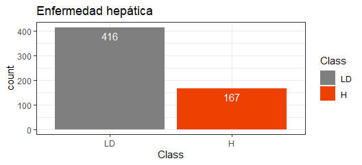

Figure 1: Gráfico de barras variable respuesta.

Para que un modelo predictivo sea útil, debe de tener un porcentaje de acierto superior a lo esperado por azar o a un determinado nivel basal. En problemas de clasificación, el nivel basal es el que se obtiene si se asignan todas las observaciones a la clase mayoritaria (la moda).

```r
# Porcentaje de aciertos si se predice para todas las observaciones que padecen LD.
n_observaciones <- nrow(ILPD)
predicciones <- rep(x = "LD",  n_observaciones)
mean(predicciones == ILPD$Class) * 100 # porcentaje mínimo que hay que intentar superar con los modelos predictivos
```

```
[1] 71.35506
```

En base a estos datos, el porcentaje mínimo que hay que intentar superar con los modelos predictivos es del 71.36%.

### Distribución de las variables contínuas

Preparamos un conjunto de datos sin valores ausentes para poder explorar los datos de las variables contínuas, ya que algunos análisis no soportan los valores ausentes. Creamos un nuevo conjunto de datos llamado `data4` eliminando los registos con valores NA. Como tenemos un número adecuado registros y pocos valores faltantes, podemos eliminar los registros que contengan valores NA y trabajar solamente con los registros completos ya que no perderemos mucha información.

```r
## Eliminamos los registros con NAs
data4 <- ILPD[complete.cases(ILPD),]
```

El nuevo conjunto de datos `data4` está formado por 11 variables y 579 registros completos. Mostramos los primeros 6 registros:

Table 7: Primeros 6 registros del conjunto data4.

| Age | Gender | TB | DB | Alkphos | Sgpt | Sgot | TP | ALB | AG | Class |
| --- | --- | --- | --- | --- | --- | --- | --- | --- | --- | --- |
| 65 | Female | 0.7 | 0.1 | 187 | 16 | 18 | 6.8 | 3.3 | 0.90 | LD |
| 62 | Male | 10.9 | 5.5 | 699 | 64 | 100 | 7.5 | 3.2 | 0.74 | LD |
| 62 | Male | 7.3 | 4.1 | 490 | 60 | 68 | 7.0 | 3.3 | 0.89 | LD |
| 58 | Male | 1.0 | 0.4 | 182 | 14 | 20 | 6.8 | 3.4 | 1.00 | LD |
| 72 | Male | 3.9 | 2.0 | 195 | 27 | 59 | 7.3 | 2.4 | 0.40 | LD |
| 46 | Male | 1.8 | 0.7 | 208 | 19 | 14 | 7.6 | 4.4 | 1.30 | LD |

Tras eliminar los valores faltantes comprobamos el número de registros en las variables categóricas.

Comprobamos que el número de muestras para cada clase:

Table 8: Cantidad de muestras de cada clase en el conjunto de datos data4.

| LD | H |
| --- | --- |
| 414 | 165 |

El procentaje de muestras de cada clase en el conjunto de datos es:

Table 9: Poncentaje de muestras de cada clase en el conjunto de datos data4.

| LD | H |
| --- | --- |
| 0.72 | 0.28 |

Comprobamos el número de muestras de cada género:

Table 10: Cantidad de muestras de cada género en el conjunto de datos data4.

| Female | Male |
| --- | --- |
| 140 | 439 |

Ante estos datos, observamos que el porcentaje de muestras de cada clase apenas ha variado y que el porcentaje de muestras por género es idéntico. Esto se debe de los 4 registros eliminados había dos de cada clase y género permitiendo mantener el mismo porcentaje de clases que el conjunto de datos original.

Primero realizamos un breve resumen estadístico de las variables numéricas del conjunto sin valores ausentes:

Table 11: Estadísticas descriptivas de las variables numéricas

|  | Min. | 1st Qu. | Median | Mean | 3rd Qu. | Max. |
| --- | --- | --- | --- | --- | --- | --- |
| Age | 4.0 | 33.0 | 45.00 | 44.78 | 58.0 | 90.0 |
| TB | 0.4 | 0.8 | 1.00 | 3.32 | 2.6 | 75.0 |
| DB | 0.1 | 0.2 | 0.30 | 1.49 | 1.3 | 19.7 |
| Alkphos | 63.0 | 175.5 | 208.00 | 291.37 | 298.0 | 2110.0 |
| Sgpt | 10.0 | 23.0 | 35.00 | 81.13 | 61.0 | 2000.0 |
| Sgot | 10.0 | 25.0 | 42.00 | 110.41 | 87.0 | 4929.0 |
| TP | 2.7 | 5.8 | 6.60 | 6.48 | 7.2 | 9.6 |
| ALB | 0.9 | 2.6 | 3.10 | 3.14 | 3.8 | 5.5 |
| AG | 0.3 | 0.7 | 0.93 | 0.95 | 1.1 | 2.8 |

Observamos que el resumen estadístico de las variables numéricas es normal y se corresponde con lo esperado respecto a la descripción del conjunto de datos. Por ejemplo, el rango superior de la variable `Age` es correcto ya que cualquier paciente cuya edad supere los 89 años figura como “de 90 años”. Una cosa a tener en cuenta es que el rango de las variables es muy distinto, por lo que hay que considerar normalizar los datos en caso de que el algoritmo lo requiera.

Debido a que no trabajamos con una gran cantidad de variables, podemos realizar una exploración gráfica de las variables numéricas mediante distintos tipos de gráficos.

Primero realizamos una exploración general de todas las variables numéricas mediante boxplots.

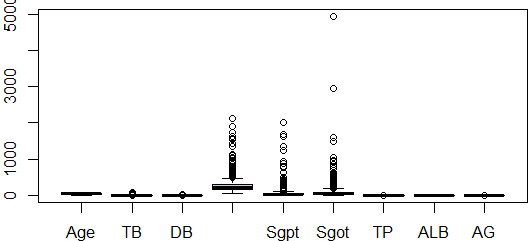

Figure 2: Boxplots de las variables numéricas.

Como se observa en el gráfico el rango de variabilidad entre variables es muy grande por eso en algunos casos con rango de valores muy estrechos queda reducida la caja a una linea. Además, se observa un gran número de valores extremos en algunas variables.

También realizamos los gráficos de dispersión enfrentando todas las variables numéricas entre sí:

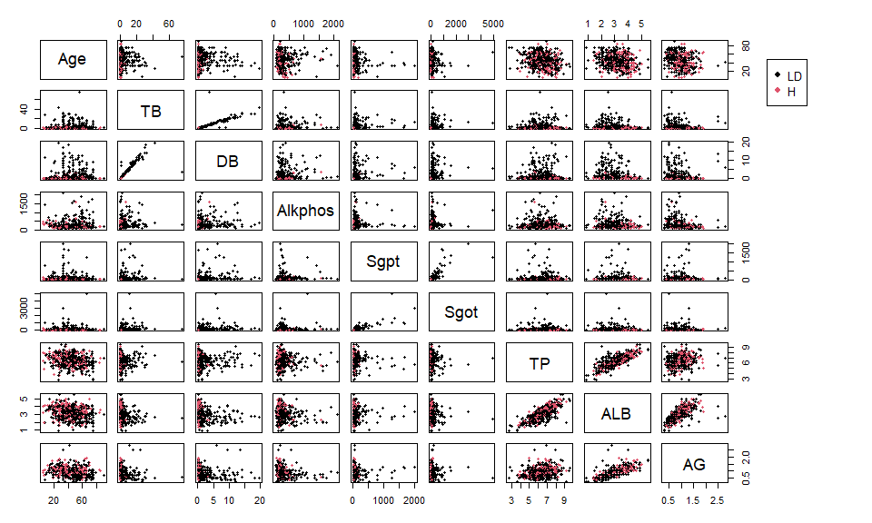

Figure 3: Gráficos de dispersión entre las variables numéricas.

En estos gráficos obervamos algunas variables parecen estar correlacionadas y que en algunos casos se observa una diferencias en la distribución de las nubes de puntos de las clases LD y H.

A continuación vamos a estudiar la distribución de las variables contínuas mediante histogramas:

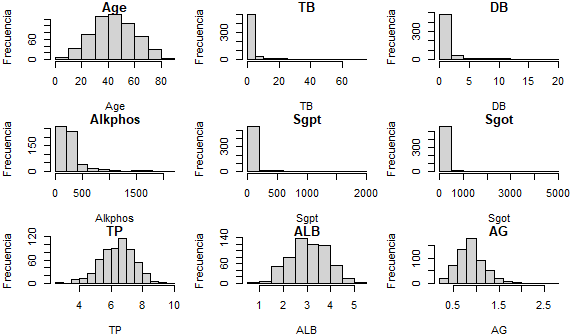

Figure 4: Histogramas de las variables numéricas.

Observamos que las variables `TB`, `DB`, `Alkphos`, `Sgpt` y `Sgot` tienen una distribución asimétrica. Este tipo de distribución suele visualizarse mejor tras una trasformación logarítmica. Por lo tanto, volvemos a estudiar la distribución de las variables teniendo esto en cuenta, pero en lugar de realizar un histograma, representamos cada variable en un gráfico de densidad y boxplot en función de la clase a la que pertenecen los datos. También realizamos un breve resumen estadístico de cada variable en función de la clase.

**Age**

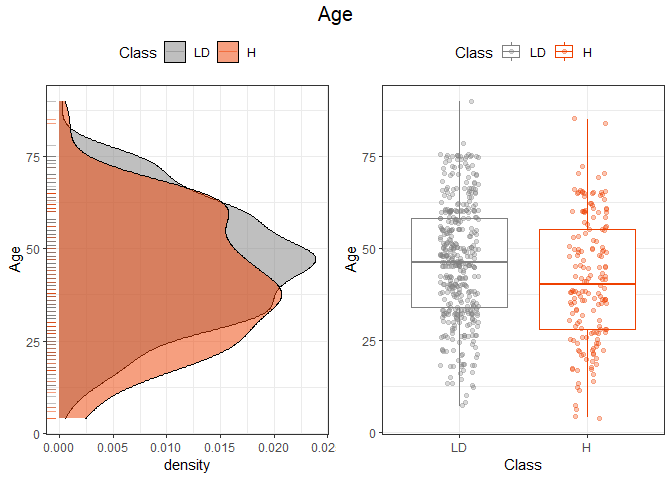

Figure 5: Gráficos variable Age.

Table 12: Estadísticas descriptivas de la variable Age por clase.

| Class | media | mediana | min | max |
| --- | --- | --- | --- | --- |
| LD | 46.15 | 46 | 7 | 90 |
| H | 41.24 | 40 | 4 | 85 |

**TB**

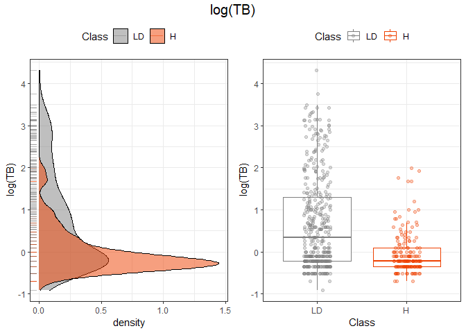

Figure 6: Gráficos variable TB.

Table 13: Estadísticas descriptivas de la variable TB por clase.

| Class | media | mediana | min | max |
| --- | --- | --- | --- | --- |
| LD | 4.16 | 1.4 | 0.4 | 75.0 |
| H | 1.14 | 0.8 | 0.5 | 7.3 |

**DB**

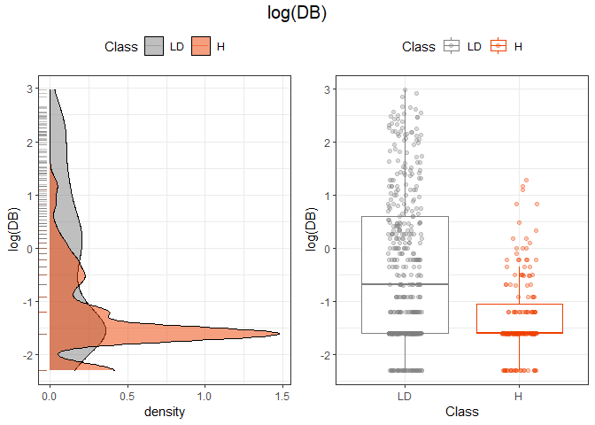

Figure 7: Gráficos variable DB.

Table 14: Estadísticas descriptivas de la variable DB por clase.

| Class | media | mediana | min | max |
| --- | --- | --- | --- | --- |
| LD | 1.92 | 0.5 | 0.1 | 19.7 |
| H | 0.40 | 0.2 | 0.1 | 3.6 |

**Alkphos**

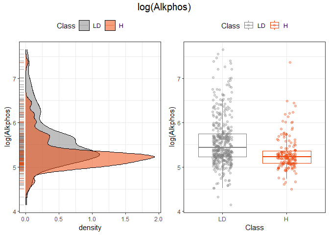

Figure 8: Gráficos variable Alkphos.

Table 15: Estadísticas descriptivas de la variable Alkphos por clase.

| Class | media | mediana | min | max |
| --- | --- | --- | --- | --- |
| LD | 319.01 | 229 | 63 | 2110 |
| H | 219.75 | 186 | 90 | 1580 |

**Sgpt**

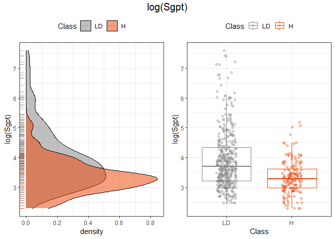

Figure 9: Gráficos variable Sgpt.

Table 16: Estadísticas descriptivas de la variable Sgpt por clase.

| Class | media | mediana | min | max |
| --- | --- | --- | --- | --- |
| LD | 99.61 | 41 | 12 | 2000 |
| H | 33.65 | 27 | 10 | 181 |

**Sgot**

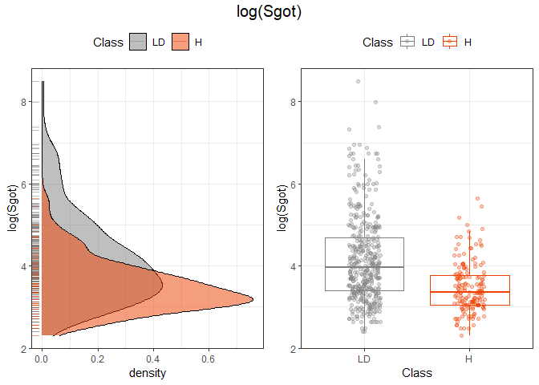

Figure 10: Gráficos variable Sgot.

Table 17: Estadísticas descriptivas de la variable Sgot por clase.

| Class | media | mediana | min | max |
| --- | --- | --- | --- | --- |
| LD | 137.70 | 52.5 | 11 | 4929 |
| H | 40.69 | 29.0 | 10 | 285 |

**TP**

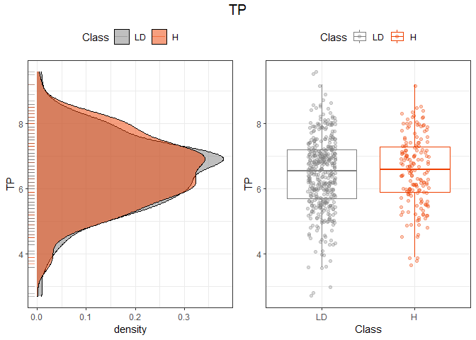

Figure 11: Gráficos variable TP.

Table 18: Estadísticas descriptivas de la variable TP por clase.

| Class | media | mediana | min | max |
| --- | --- | --- | --- | --- |
| LD | 6.46 | 6.55 | 2.7 | 9.6 |
| H | 6.54 | 6.60 | 3.7 | 9.2 |

**ALB**

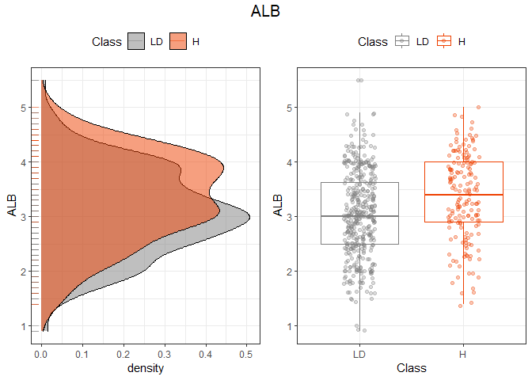

Figure 12: Gráficos variable ALB.

Table 19: Estadísticas descriptivas de la variable ALB por clase.

| Class | media | mediana | min | max |
| --- | --- | --- | --- | --- |
| LD | 3.06 | 3.0 | 0.9 | 5.5 |
| H | 3.34 | 3.4 | 1.4 | 5.0 |

**AG**

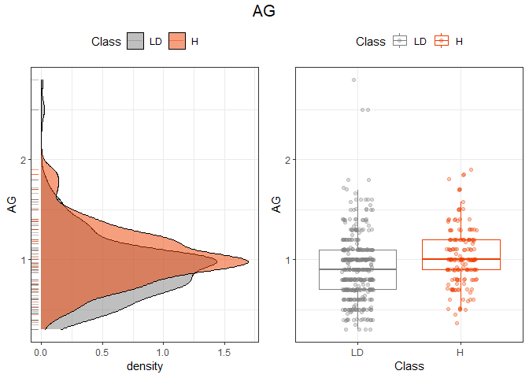

Figure 13: Gráficos variable AG.

Table 20: Estadísticas descriptivas de la variable AG por clase.

| Class | media | mediana | min | max |
| --- | --- | --- | --- | --- |
| LD | 0.91 | 0.9 | 0.30 | 2.8 |
| H | 1.03 | 1.0 | 0.37 | 1.9 |

También realizamos una tabla con el resumen estadístico de todas las variables continuas por clase:

Table 21: Estadísticas descriptivas de las variables numéricas por clase.

|  | Min. | 1st Qu. | Median | Mean | 3rd Qu. | Max. |
| --- | --- | --- | --- | --- | --- | --- |
| Age LH | 7.00 | 34.00 | 46.00 | 46.14 | 58.00 | 90.0 |
| Age H | 4.00 | 28.00 | 41.00 | 41.36 | 55.00 | 85.0 |
| TB LH | 0.40 | 0.80 | 1.40 | 4.18 | 3.68 | 75.0 |
| TB H | 0.50 | 0.70 | 0.80 | 1.14 | 1.10 | 7.3 |
| DB LH | 0.10 | 0.20 | 0.50 | 1.93 | 1.80 | 19.7 |
| DB H | 0.10 | 0.20 | 0.20 | 0.40 | 0.30 | 3.6 |
| Alkphos LH | 63.00 | 186.00 | 229.00 | 319.54 | 315.75 | 2110.0 |
| Alkphos H | 90.00 | 162.00 | 187.00 | 220.68 | 215.00 | 1580.0 |
| Sgpt LH | 12.00 | 25.00 | 41.00 | 99.97 | 77.50 | 2000.0 |
| Sgpt H | 10.00 | 20.00 | 28.00 | 33.84 | 38.00 | 181.0 |
| Sgot LH | 11.00 | 29.25 | 53.00 | 138.17 | 110.25 | 4929.0 |
| Sgot H | 10.00 | 21.00 | 29.00 | 40.76 | 43.00 | 285.0 |
| TP LH | 2.70 | 5.70 | 6.55 | 6.46 | 7.20 | 9.6 |
| TP H | 3.70 | 5.90 | 6.60 | 6.54 | 7.30 | 9.2 |
| ALB LH | 0.90 | 2.50 | 3.00 | 3.06 | 3.60 | 5.5 |
| ALB H | 1.40 | 2.90 | 3.40 | 3.34 | 4.00 | 5.0 |
| AG LH | 0.30 | 0.70 | 0.90 | 0.91 | 1.10 | 2.8 |
| AG H | 0.37 | 0.90 | 1.00 | 1.03 | 1.20 | 1.9 |

Los datos parecen ser correctos, por lo que podemos continuar con el análisis.

### Distribución de las variables cualitativas:

Estudiamos la distribución de la variable Gender:

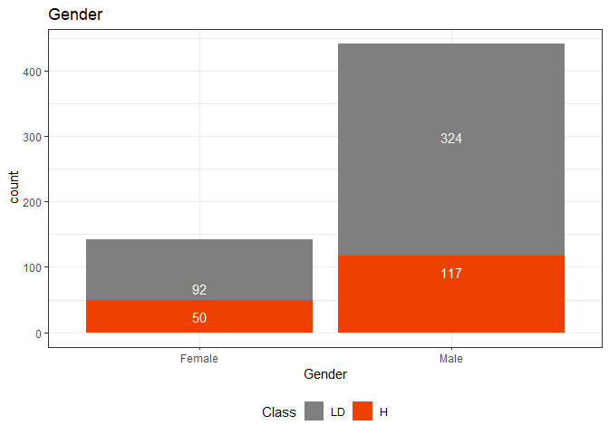

Figure 14: Distribución variable Gender.

Table 22: Poncentaje de muestras de cada clase por género en el conjunto de datos ILPD.

|  | LD | H |
| --- | --- | --- |
| Female | 0.65 | 0.35 |
| Male | 0.74 | 0.26 |

### Importancia de las variables:

La representación gráfica de la distribución de las variables en función de si los pacientes sufren enfermedad hepática o no, ayuda a tener una idea de qué variables pueden ser buenos predictores para el modelo y cuales no aportan información o la que aportan esredundante. Aunque la creación de un buen modelo debe entenderse como un proceso iterativo, en el que se van ajustando y probando distintos modelos, existen ciertas pistas que pueden ayudar a realizar una selección inicial adecuada.

**Correlación entre variables continuas**

Si dos variables numéricas están muy correlacionadas, añaden información redundante al modelo, por lo tanto, noconviene incorporar ambas. Si esto ocurre, se puede: excluir aquella que, acorde al criterio del analista, no estárealmente asociada con la variable respuesta; o combinarlas para recoger toda su información en una única nuevavariable, por ejemplo, con un PCA.

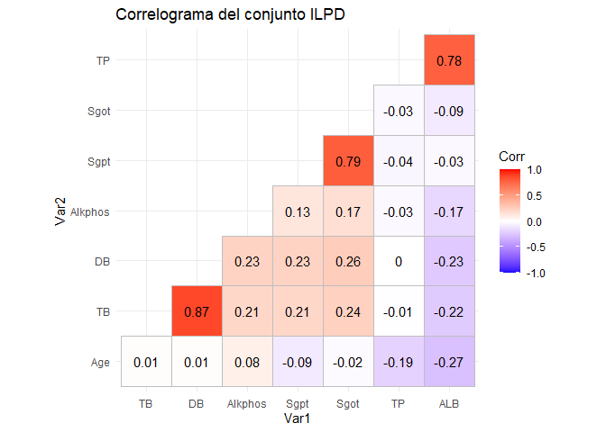

```r
# Matriz de correlación (correlación de Pearson)
library(ggcorrplot)
ggcorrplot(cor(ILPD[num_index]), method="square",
           type="lower", lab=TRUE) +
  ggtitle("Correlograma del conjunto ILPD") +
  theme_minimal()
```

```r
cor_pmat(ILPD[num_index]) # p-valor Pearson
```

```
                 Age            TB            DB      Alkphos          Sgpt
Age     0.000000e+00  7.768594e-01  8.560486e-01 5.227514e-02  3.596851e-02
TB      7.768594e-01  0.000000e+00 7.873553e-185 4.807661e-07  1.806788e-07
DB      8.560486e-01 7.873553e-185  0.000000e+00 9.408583e-09  1.098340e-08
Alkphos 5.227514e-02  4.807661e-07  9.408583e-09 0.000000e+00  2.364670e-03
Sgpt    3.596851e-02  1.806788e-07  1.098340e-08 2.364670e-03  0.000000e+00
Sgot    6.314072e-01  6.105939e-09  2.755666e-10 4.972036e-05 1.352081e-126
TP      5.187182e-06  8.452792e-01  9.973329e-01 4.919867e-01  3.054205e-01
ALB     6.804151e-11  5.868188e-08  2.403421e-08 5.968622e-05  4.735335e-01
AG      1.452399e-07  5.542940e-07  1.208322e-06 1.184795e-08  9.545256e-01
                 Sgot            TP           ALB           AG
Age      6.314072e-01  5.187182e-06  6.804151e-11 1.452399e-07
TB       6.105939e-09  8.452792e-01  5.868188e-08 5.542940e-07
DB       2.755666e-10  9.973329e-01  2.403421e-08 1.208322e-06
Alkphos  4.972036e-05  4.919867e-01  5.968622e-05 1.184795e-08
Sgpt    1.352081e-126  3.054205e-01  4.735335e-01 9.545256e-01
Sgot     0.000000e+00  5.365819e-01  3.952294e-02 9.222926e-02
TP       5.365819e-01  0.000000e+00 1.934141e-122 1.065523e-08
ALB      3.952294e-02 1.934141e-122  0.000000e+00 6.399343e-83
AG       9.222926e-02  1.065523e-08  6.399343e-83 0.000000e+00
```

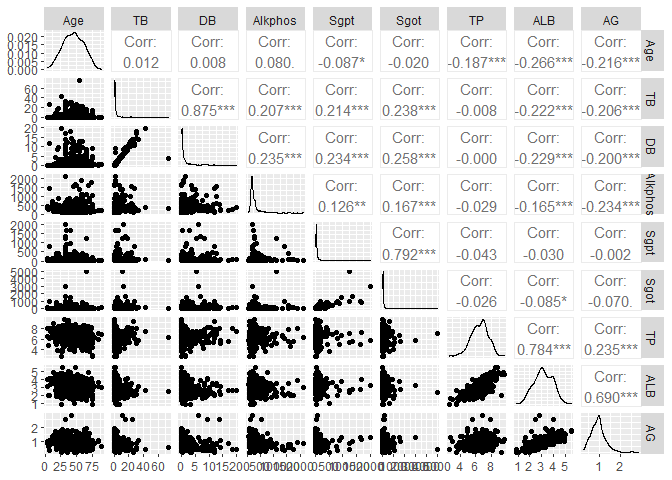

```r
# Gráfico de disperión y matriz de correlación
library(GGally)
ggpairs(ILPD[num_index])
```

```r
# Test de Pearson
cor.test(ILPD$DB, ILPD$TB)
```

```
    Pearson's product-moment correlation

data:  ILPD$DB and ILPD$TB
t = 43.484, df = 581, p-value < 2.2e-16
alternative hypothesis: true correlation is not equal to 0
95 percent confidence interval:
 0.8540723 0.8924387
sample estimates:
      cor
0.8746179
```

Observamos varios casos con una correlación superior a 0,5 lo que puede indicar que alguna de las variables implicadas no aporte nueva información al modelo. Por lo tanto, hay que prestar atención a estas variables. Consideramos eliminar las variables que presenten una correlación superrior a 0.7 y que en base a sus características consideramos que son `DB`, `Sgot` y `ALB`. Consideramos estás variables porque son menos específicas de enfermedad hepática, ya que pueden ser producidas por otras partes del cuermo que no son el hígado y que su liberación no sea causada por enfermedad hepática. Por lo tanto, a la hora de crear los modelos comprobaremos si al eliminar estas variables el rendimiento mejora.

**Variables con varianza cero o próxima a cero**

Si una variable tiene varianza igual o próxima a cero (su valor es el mismo o casi el mismo para todas las observaciones) añade al modelo más ruido que información, por lo que suele ser conveniente excluirla.

```r
# Varianza de las variables numéricas
round(apply(data4[num_index], 2, var),2)
```

```
     Age       TB       DB  Alkphos     Sgpt     Sgot       TP      ALB
  263.15    38.78     7.93 59322.38 33555.95 84013.04     1.18     0.63
      AG
    0.10
```

```r
library(caret)
nearZeroVar(data4[num_index], saveMetrics = TRUE)
```

```
        freqRatio percentUnique zeroVar   nzv
Age      1.416667     12.435233   FALSE FALSE
TB       1.168831     19.516408   FALSE FALSE
DB       3.047619     13.816926   FALSE FALSE
Alkphos  1.000000     45.250432   FALSE FALSE
Sgpt     1.043478     26.252159   FALSE FALSE
Sgot     1.142857     30.569948   FALSE FALSE
TP       1.066667     10.017271   FALSE FALSE
ALB      1.216216      6.908463   FALSE FALSE
AG       1.630769     11.917098   FALSE FALSE
```

Entre los predictores incluidos en el modelo, no se detecta ninguno con varianza cero o próxima a cero.

**Importancia de las variables con Random Forest**

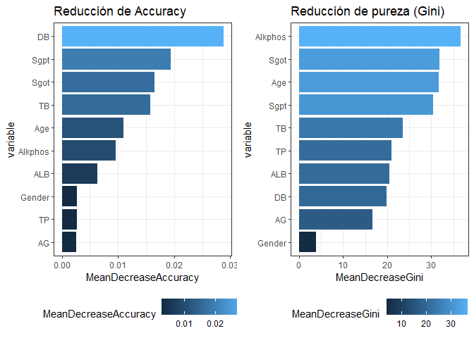

```r
## Importancia de las variables con Random Forest:
library(randomForest)
library(tibble)

modelo_randforest <- randomForest(formula = Class ~ . ,
                                  data = data4,
                                  mtry = 5,
                                  importance = TRUE,
                                  ntree = 1000)

# he nclass + 1st column is the mean descrease in accuracy over
# all classes. The last column is the mean decrease in Gini index.
importancia <- as.data.frame(modelo_randforest$importance)
importancia <- rownames_to_column(importancia,var = "variable")

library(ggpubr)

p1 <- ggplot(data = importancia, aes(x = reorder(variable, MeanDecreaseAccuracy),
                                     y = MeanDecreaseAccuracy,
                                     fill = MeanDecreaseAccuracy)) +
  labs(x = "variable", title = "Reducción de Accuracy") +
  geom_col() +
  coord_flip() +
  theme_bw() +
  theme(legend.position = "bottom")

p2 <- ggplot(data = importancia, aes(x = reorder(variable, MeanDecreaseGini),
                                     y = MeanDecreaseGini,
                                     fill = MeanDecreaseGini)) +
  labs(x = "variable", title = "Reducción de pureza (Gini)") +
  geom_col() +
  coord_flip() +
  theme_bw() +
  theme(legend.position = "bottom")
ggarrange(p1, p2)
```

Los análisis difieren en cuanto a qué variables son más importantes. Las comunes con mayor importancia son `Sgpt`, `Sgot`, `TB`, `Age` y `Alkphos`.

### División de los datos en entrenamiento y test:

Conjuntos train y test

```r
# Excluimos los registros con NAs
ILPD_less <- ILPD[complete.cases(ILPD), ]

# Partici?n de los datos train/test
library(caret)
set.seed(123)
## Muestras que pertenecen al conjunto train
in_train <- createDataPartition(ILPD_less$Class,
                                p = 0.7, list = FALSE)

## Creamos los conjuntos train y test:
data_train <- ILPD_less[in_train,]
data_test <- ILPD_less[-in_train,]

## Variable objetivo por conjunto de datos
train_labels <- ILPD_less[in_train,length(ILPD_less)]
test_labels <- ILPD_less[-in_train,length(ILPD_less)]
```

Este tipo de reparto estratificado asegura que el conjunto de entrenamiento y el de test sean similares en cuanto a la variable respuesta, sin embargo, no garantiza que ocurra lo mismo con los predictores. Por ejemplo, en un set de datos con 100 observaciones, un predictor binario que tenga 90 observaciones de un grupo y solo 10 de otro, tiene un alto riesgo de que,en alguna de las particiones, el grupo minoritario no tenga representantes. Si esto ocurre en el conjunto de entrenamiento,algunos algoritmos darán error al aplicarlos al conjunto de test, ya que no entenderán el valor que se les está pasando. Este problema puede evitarse eliminando variables con varianza próxima a cero.

De los 579 registros iniciales, el conjunto *train* (`data_train`) contiene 406 registros y el conjunto *test* (`data_test`) contiene 173 registros. Los porcentajes parecen indicar que los datos se han dividido equitativamente entre los subconjuntos de datos.

Table 23: Porcentaje de cada tipo de localización en los conjuntos train y test.

|  | LD | H |
| --- | --- | --- |
| % Train | 0.71 | 0.29 |
| % Test | 0.72 | 0.28 |

## Preprocesar los datos:

```r
# Preparamos los conjuntos de datos para que sean preprocesados
data_train_prep <- data_train
data_test_prep  <- data_test
```

### Eliminar variables con varianza 0 o próxima:

```r
## Se crea un objeto recipe() con la variable respuesta y los predictores.
library(recipes)
objeto_recipe <- recipe(formula = Class ~ .,
                        data =  data_train_prep)
objeto_recipe
```

```
Recipe

Inputs:

      role #variables
   outcome          1
 predictor         10
```

```r
# Eliminamos variables con varianza 0 o próxima
# objeto_recipe <- objeto_recipe %>% step_nzv(all_numeric_predictors())
objeto_recipe <- objeto_recipe %>% step_nzv(all_predictors())
objeto_recipe
```

```
Recipe

Inputs:

      role #variables
   outcome          1
 predictor         10

Operations:

Sparse, unbalanced variable filter on all_predictors()
```

### Normalización de los datos:

Normalizamos por medio de la estandarización min-max de modo que se encuentren en el rango [0,1].

```r
## Normalización de los datos
objeto_recipe <- objeto_recipe %>% step_range(all_numeric_predictors())
objeto_recipe
```

```
Recipe

Inputs:

      role #variables
   outcome          1
 predictor         10

Operations:

Sparse, unbalanced variable filter on all_predictors()
Range scaling to [0,1] for all_numeric_predictors()
```

### Binarización de variables cualitativas:

La binarización consiste en crear nuevas variables dummy con cada uno de los niveles de las variables cualitativas.

```r
# Binarizamos las variables cualitativas
objeto_recipe <- objeto_recipe %>% step_dummy(all_nominal(), - all_outcomes())
objeto_recipe
```

```
Recipe

Inputs:

      role #variables
   outcome          1
 predictor         10

Operations:

Sparse, unbalanced variable filter on all_predictors()
Range scaling to [0,1] for all_numeric_predictors()
Dummy variables from all_nominal(), -all_outcomes()
```

### Conjuntos train y test preprocesados

Aplicamos los cambios guardados en el objeto recipe a los conjuntos train y test.

```r
## Entrenar el objeto recipe
trained_recipe <- prep(objeto_recipe, training = data_train)
trained_recipe
```

```
Recipe

Inputs:

      role #variables
   outcome          1
 predictor         10

Training data contained 406 data points and no missing data.

Operations:

Sparse, unbalanced variable filter removed no terms [trained]
Range scaling to [0,1] for Age, TB, DB, Alkphos, Sgpt, Sgot, TP, ALB, AG [trained]
Dummy variables from Gender [trained]
```

```r
## Se aplican las transformaciones al conjunto de entrenamiento y de test
data_train_prep <- bake(trained_recipe, new_data = data_train)
data_test_prep  <- bake(trained_recipe, new_data = data_test)

glimpse(data_train_prep)
```

```
Rows: 406
Columns: 11
$ Age         <dbl> 0.6744186, 0.6279070, 0.7906977, 0.2558140, 0.5930233, 0.6~
$ TB          <dbl> 0.245862884, 0.011820331, 0.080378251, 0.009456265, 0.0047~
$ DB          <dbl> 0.275510204, 0.015306122, 0.096938776, 0.005102041, 0.0051~
$ Alkphos     <dbl> 0.34697218, 0.06492089, 0.07201309, 0.04964539, 0.12384070~
$ Sgpt        <dbl> 0.027135678, 0.002010050, 0.008542714, 0.003015075, 0.0216~
$ Sgot        <dbl> 0.0303236797, 0.0030664395, 0.0163543441, 0.0003407155, 0.~
$ TP          <dbl> 0.6956522, 0.5942029, 0.6666667, 0.6231884, 0.5942029, 0.4~
$ ALB         <dbl> 0.5000000, 0.5434783, 0.3260870, 0.5652174, 0.5434783, 0.3~
$ AG          <dbl> 0.176, 0.280, 0.040, 0.280, 0.280, 0.200, 0.120, 0.280, 0.~
$ Class       <fct> LD, LD, LD, LD, LD, LD, LD, LD, LD, H, LD, H, LD, LD, H, L~
$ Gender_Male <dbl> 1, 1, 1, 0, 1, 1, 1, 0, 1, 1, 1, 1, 0, 1, 1, 1, 1, 1, 1, 1~
```

Tras el preprocesado de los datos, se han generado un total de 11 variables (10 predictores y la variable respuesta).

## Selección de predictores:

Cuando se entrena un modelo, es importante incluir como predictores únicamente aquellas variables que están realmente relacionadas con la variable respuesta, ya que son estas las que contienen información útil para el modelo. Incluir un exceso de variables suele conllevar una reducción de la capacidad predictiva del modelo cuando se expone a nuevos datos (*overfitting*). Aunque para este caso de estudio, el número de predictores es considerablemente reducido, la selección de predictores puede suponer la diferencia entre un modelo normal y uno muy bueno.

Algunos algoritmos de machine learning (random forest, lasso, boosting…) contienen sus propias estrategias para seleccionar predictores, de ahí que sean modelos tan versátiles. A parte de estos, los métodos para reducir el número de predictores previo ajuste del modelo pueden agruparse en dos categorías: métodos wrapper y métodos de filtrado.

Los métodos wrapper evalúan múltiples modelos, generados mediante la incorporación o eliminación de predictores, con la finalidad de identificar la combinación óptima que consigue maximizar la capacidad del modelo. Pueden entenderse como algoritmos de búsqueda que tratan a los predictores disponibles como valores de entrada y utilizan una métrica del modelo, por ejemplo, su error de predicción, como objetivo de la optimización.

Los métodos basados en filtrado evalúan la relevancia de los predictores fuera del modelo para, posteriormente, incluir únicamente aquellos que pasan un determinado criterio. Se trata por lo tanto de analizar la relación que tiene cada predictor con la variable respuesta.

Ambas estrategias, wrapper y filtrado, tienen ventajas y desventajas. Los métodos de filtrado son computacionalmente más rápidos por lo que suelen ser la opción factible cuando hay cientos o miles de predictores, sin embargo, el criterio de selección no está directamente relacionado con la efectividad del modelo. Además, en la mayoría de casos, los métodos de filtrado evalúan cada predictor de forma individual, por lo que no contemplan interacciones y pueden incorporar predictores redundantes (correlacionados). Los métodos wrapper, además de ser computacionalmente más costosos, para evitar overfitting, necesitan recurrir a validación cruzada o bootstrapping, por lo que requieren un número alto de observaciones. A pesar de ello, si se cumplen las condiciones, suelen conseguir una mejor selección.

### Métodos wrapper

En nuestro caso, el paquete caret incorpora métodos wrapper basados en eliminación recursiva.

La eliminación recursiva es una estrategia muy práctica para evitar comprobar todas las posibles combinaciones de variables (búsqueda exhaustiva), que es muy costosa computacionalmente.

Realizamos una eliminación recursiva mediente **Random Forest y Bootstraping**:

```r
# Eliminación recursiva mediante Random Forest y Bootstraping

# Tamaño de los conjuntos de predictores analizados
subsets <- c(1:10)

# Número de resamples para el proceso de bootstrapping
repeticiones <- 30

# Se crea una semilla para cada repetición de validación. Esto solo es necesario si
# se quiere asegurar la reproducibilidad de los resultados, ya que la validación
# cruzada y el bootstrapping implican selección aleatoria.

# El número de semillas necesarias depende del número total de repeticiones:
# Se necesitan B+1 elementos donde B es el número total de particiones (CV) o
# resampling (bootstrapping). Los primeros B elementos deben ser vectores formados
# por M números enteros, donde M es el número de modelos ajustados, que en este caso
# se corresponde con el número de tamaños. El último elemento solo necesita un único
# número para ajustar el modelo final.
set.seed(123)
seeds <- vector(mode = "list", length = repeticiones + 1)
for (i in 1:repeticiones) {
  seeds[[i]] <- sample.int(1000, length(subsets))
}
seeds[[repeticiones + 1]] <- sample.int(1000, 1)

# Se crea un control de entrenamiento donde se define el tipo de modelo empleado
# para la selección de variables, en este caso random forest, la estrategia de
# resampling, en este caso bootstrapping con 30 repeticiones, y las semillas para
# cada repetición. Con el argumento returnResamp = "all" se especifica que se
# almacene la información de todos los modelos generados en todas las repeticiones.
ctrl_rfe <- rfeControl(functions = rfFuncs, method = "boot", number = repeticiones,
                       returnResamp = "all", allowParallel = TRUE, verbose = FALSE,
                       seeds = seeds)

# Se ejecuta la eliminación recursiva de predictores
set.seed(342)
rf_rfe <- rfe(Class ~ ., data = data_train_prep,
              sizes = subsets,
              metric = "Accuracy",
              # El accuracy es la proporción de clasificaciones correctas
              rfeControl = ctrl_rfe,
              ntree = 500)
# Dentro de rfe() se pueden especificar argumentos para el modelo empleado, por
# ejemplo, el hiperparámetro ntree=500.

# Se muestra una tabla resumen con los resultados
rf_rfe
```

```
Recursive feature selection

Outer resampling method: Bootstrapped (30 reps)

Resampling performance over subset size:

 Variables Accuracy   Kappa AccuracySD KappaSD Selected
         1   0.6247 0.03214    0.04182 0.08356
         2   0.6714 0.15884    0.03771 0.09136
         3   0.6812 0.16052    0.03685 0.09729
         4   0.6757 0.15708    0.02850 0.07223
         5   0.6878 0.17489    0.03407 0.08268
         6   0.6875 0.17328    0.02994 0.06594
         7   0.6874 0.16762    0.03379 0.07693
         8   0.6921 0.17525    0.03365 0.08266
         9   0.6907 0.17237    0.03030 0.06743
        10   0.6928 0.18050    0.03218 0.07514        *

The top 5 variables (out of 10):
   Alkphos, Age, Sgpt, Sgot, TB
```

```r
# El objeto rf_rfe almacena en optVariables las variables del mejor modelo.
rf_rfe$optVariables
```

```
 [1] "Alkphos"     "Age"         "Sgpt"        "Sgot"        "TB"
 [6] "TP"          "AG"          "ALB"         "DB"          "Gender_Male"
```

```r
# Guardamos en una variable los predictores filtrados para emplearlos
# posteriormente en el ajuste de los modelos.
predictores_filtrados_rf <- as.formula(paste("Class",
                                             paste(rf_rfe$optVariables,
                                                   collapse=" + "), sep=" ~ "))
```

El resultado indica que el mejor modelo se consigue con 10 predictores. Estudiamos más a fondo los resultados de la selección:

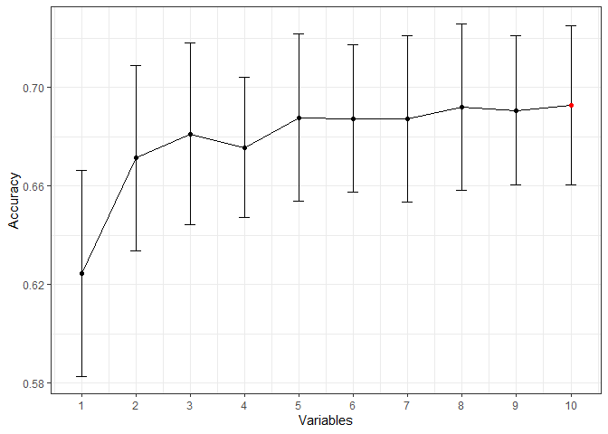

```r
# Evolución del accuracy estimado en función del número de predictores incluido en el modelo.
ggplot(data = rf_rfe$results, aes(x = Variables, y = Accuracy)) +
  geom_line() +
  scale_x_continuous(breaks  = unique(rf_rfe$results$Variables)) +
  geom_point() +
  geom_errorbar(aes(ymin = Accuracy - AccuracySD, ymax = Accuracy + AccuracySD),
                width = 0.2) +
  geom_point(data = rf_rfe$results %>% slice(which.max(Accuracy)),
             color = "red") +
  theme_bw()
```

Realizamos un **Algoritmo Genético con CrossValidation**:

```r
# Control de entrenamiento
ga_ctrl <- gafsControl(functions = rfGA,
                       method = "cv",
                       number = 5,
                       allowParallel = TRUE,
                       genParallel = TRUE,
                       verbose = FALSE)

# Selección de predictores
set.seed(10)
rf_ga <- gafs(x = data_train_prep %>% select(-Class),
              y = data_train_prep$Class,
              iters = 10,
              popSize = 50,
              gafsControl = ga_ctrl,
              ntree = 100)

# Se muestra una tabla resumen con los resultados
rf_ga
```

```
Genetic Algorithm Feature Selection

406 samples
10 predictors
2 classes: 'LD', 'H'

Maximum generations: 10
Population per generation: 50
Crossover probability: 0.8
Mutation probability: 0.1
Elitism: 0

Internal performance values: Accuracy, Kappa
Subset selection driven to maximize internal Accuracy

External performance values: Accuracy, Kappa
Best iteration chose by maximizing external Accuracy
External resampling method: Cross-Validated (5 fold)

During resampling:
  * the top 5 selected variables (out of a possible 10):
    TB (80%), Age (60%), DB (60%), Gender_Male (60%), Sgpt (60%)
  * on average, 4.6 variables were selected (min = 3, max = 6)

In the final search using the entire training set:
   * 6 features selected at iteration 3 including:
     Age, TB, Sgot, TP, AG ...
   * external performance at this iteration is

   Accuracy       Kappa
     0.7020      0.1519
```

```r
# El objeto rf_ga almacena en optVariables las variables del mejor modelo.
rf_ga$optVariables
```

```
[1] "Age"         "TB"          "Sgot"        "TP"          "AG"
[6] "Gender_Male"
```

```r
# Guardamos en una variable los predictores filtrados para emplearlos
# posteriormente en el ajuste de los modelos.
predictores_filtrados_ag <- as.formula(paste("Class",
                                             paste(rf_ga$optVariables,
                                                   collapse=" + "), sep=" ~ "))
```

El resultado indica que el mejor modelo se consigue con 6 predictores.

### Métodos filtrado

Realizamos un método de filtrado

```r
# FILTRADO DE PREDICTORES MEDIANTE ANOVA, RANDOM FOREST Y CV-REPETIDA

# Se crea una semilla para cada partición y cada repetición: el vector debe
# tener B+1 semillas donde B = particiones * repeticiones.
particiones = 10
repeticiones = 5
set.seed(123)
seeds <- sample.int(1000, particiones * repeticiones + 1)

# Control del filtrado
ctrl_filtrado <- sbfControl(functions = rfSBF, method = "repeatedcv",
                            number = particiones, repeats = repeticiones,
                            seeds = seeds, verbose = FALSE,
                            saveDetails = TRUE, allowParallel = TRUE)
set.seed(234)
rf_sbf <- sbf(Class ~ ., data = data_train_prep,
              sbfControl = ctrl_filtrado,
              # argumentos para el modelo de evaluación
              ntree = 500)

# Se muestra una tabla resumen con los resultados
rf_sbf
```

```
Selection By Filter

Outer resampling method: Cross-Validated (10 fold, repeated 5 times)

Resampling performance:

 Accuracy  Kappa AccuracySD KappaSD
    0.695 0.1705    0.06705  0.1671

Using the training set, 8 variables were selected:
   Age, TB, DB, Alkphos, Sgpt...

During resampling, the top 5 selected variables (out of a possible 8):
   AG (100%), ALB (100%), Alkphos (100%), DB (100%), Sgot (100%)

On average, 7.9 variables were selected (min = 7, max = 8)
```

```r
# El objeto rf_sbf almacena en optVariables las variables del mejor modelo.
rf_sbf$optVariables
```

```
[1] "Age"     "TB"      "DB"      "Alkphos" "Sgpt"    "Sgot"    "ALB"
[8] "AG"
```

```r
# Guardamos en una variable los predictores filtrados para emplearlos
# posteriormente en el ajuste de los modelos.
predictores_filtrados_rfSBF <- as.formula(paste("Class",
                                                paste(rf_sbf$optVariables,
                                                      collapse=" + "), sep=" ~ "))
```

El resultado indica que el mejor modelo se consigue con 8 predictores.

### Conclusión selección de predictores

Los métodos difieren en los resultados, por lo que probaremos los tres a la hora de entrenar los modelos para ver cual presenta mejor rendimiento.

# Creación de modelos predictivos:

Utilizamos el paquete caret para generar y entrenar los diferentes modelos de aprendizaje automático. Para ello en cada caso de proponcionam diferentes hiperparámetros y se seleccionan aqullo que general el modelo con mejor rendimiento.

## Modelo k-Nearest Neighbor (KNN)

Generamos el modelo KNN

```r
# se recurre a validación cruzada repetida como método de validación.
# Número de particiones y repeticiones
particiones  <- 10
repeticiones <- 5

hiperparametros <- data.frame(k = c(5,10,15,20))

set.seed(123)
seeds <- vector(mode = "list", length = (particiones * repeticiones) + 1)
for (i in 1:(particiones * repeticiones)) {
  seeds[[i]] <- sample.int(1000, nrow(hiperparametros))
}
seeds[[(particiones * repeticiones) + 1]] <- sample.int(1000, 1)


# DEFINICIÓN DEL ENTRENAMIENTO
control_train <- trainControl(method = "repeatedcv", number = particiones,
                              repeats = repeticiones, seeds = seeds,
                              returnResamp = "final", verboseIter = FALSE,
                              allowParallel = TRUE)

# AJUSTE DEL MODELO
set.seed(342)
modelo_knn <- train(Class ~ ., data = data_train_prep,
                    method = "knn",
                    tuneGrid = hiperparametros,
                    metric = "Accuracy",
                    trControl = control_train)

modelo_knn
```

```
k-Nearest Neighbors

406 samples
 10 predictor
  2 classes: 'LD', 'H'

No pre-processing
Resampling: Cross-Validated (10 fold, repeated 5 times)
Summary of sample sizes: 365, 366, 365, 366, 366, 365, ...
Resampling results across tuning parameters:

  k   Accuracy   Kappa
   5  0.6546707  0.117748841
  10  0.6625732  0.080032564
  15  0.6829146  0.067038250
  20  0.6739634  0.003440179

Accuracy was used to select the optimal model using the largest value.
The final value used for the model was k = 15.
```

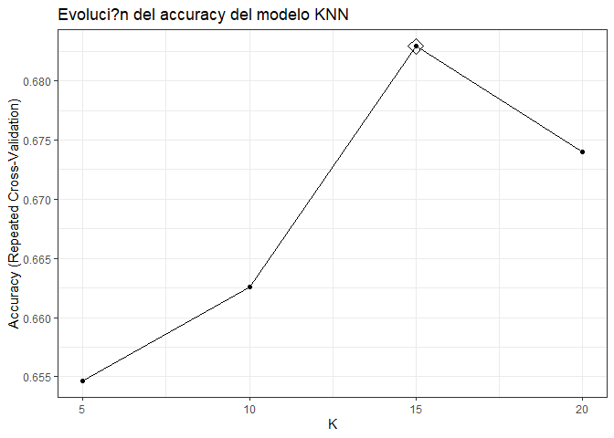

```r
# REPRESENTACIÓN GRÁFICA
library(ggplot2)
ggplot(modelo_knn, highlight = TRUE) +
  scale_x_continuous(breaks = hiperparametros$k) +
  labs(title = "Evoluci?n del accuracy del modelo KNN", x = "K") +
  theme_bw()
```

```r
# Predicciones
predicciones_knn <- predict(modelo_knn, newdata = data_test_prep,
                            type = "raw")
predicciones_knn
```

```
  [1] H  LD LD LD LD LD LD LD LD LD H  LD LD LD H  LD LD H  LD LD LD H  H  LD H
 [26] LD H  LD LD LD H  LD LD LD LD LD LD H  LD LD H  H  LD LD LD LD H  LD LD LD
 [51] LD LD LD LD LD LD LD H  H  LD LD LD LD LD LD LD LD LD LD H  LD H  LD LD LD
 [76] LD LD LD LD LD LD LD LD LD LD LD LD LD LD LD LD LD LD LD LD H  LD LD LD LD
[101] LD LD LD LD LD H  H  LD H  LD LD LD H  LD LD LD LD LD H  H  LD LD LD LD LD
[126] LD LD LD LD LD LD LD LD LD LD LD LD LD LD LD LD H  LD LD LD LD LD LD LD LD
[151] LD LD LD LD LD LD LD LD LD LD LD LD LD LD LD LD LD LD LD LD LD LD H
Levels: LD H
```

```r
# Evaluación
conf_mat_knn <- confusionMatrix(data = predicciones_knn, reference = data_test_prep$Class,
                                positive = "LD")
conf_mat_knn
```

```
Confusion Matrix and Statistics

          Reference
Prediction  LD   H
        LD 112  35
        H   12  14

               Accuracy : 0.7283
                 95% CI : (0.6556, 0.7931)
    No Information Rate : 0.7168
    P-Value [Acc > NIR] : 0.404581

                  Kappa : 0.2202

 Mcnemar's Test P-Value : 0.001332

            Sensitivity : 0.9032
            Specificity : 0.2857
         Pos Pred Value : 0.7619
         Neg Pred Value : 0.5385
             Prevalence : 0.7168
         Detection Rate : 0.6474
   Detection Prevalence : 0.8497
      Balanced Accuracy : 0.5945

       'Positive' Class : LD
```

```r
stats_class_knn <- data.frame(model         = "KNN",
                              accuracy      = conf_mat_knn$overall[[1]],
                              FN            = conf_mat_knn$table[2,1],
                              FP            = conf_mat_knn$table[1,2],
                              error.rate    = 1-conf_mat_knn$overall[[1]],
                              kappa         = conf_mat_knn$overall[[2]],
                              sensibilidad  = conf_mat_knn$byClass[[1]],
                              especificidad = conf_mat_knn$byClass[[2]],
                              precision     = conf_mat_knn$byClass[[5]],
                              recall        = conf_mat_knn$byClass[[6]],
                              f.measure     = conf_mat_knn$byClass[[7]])
stats_class_knn
```

```
  model  accuracy FN FP error.rate     kappa sensibilidad especificidad
1   KNN 0.7283237 12 35  0.2716763 0.2201976    0.9032258     0.2857143
  precision    recall f.measure
1 0.7619048 0.9032258 0.8265683
```

## Modelo Naive Bayes (NB)

Generamos el modelo NB.

```r
# se recurre a validación cruzada repetida como método de validación.
# Número de particiones y repeticiones
particiones  <- 10
repeticiones <- 5

hiperparametros <- expand.grid(usekernel = c(TRUE, FALSE),
                               fL = c(0:5),
                               adjust = c(1:5))


set.seed(123)
seeds <- vector(mode = "list", length = (particiones * repeticiones) + 1)
for (i in 1:(particiones * repeticiones)) {
  seeds[[i]] <- sample.int(1000, nrow(hiperparametros))
}
seeds[[(particiones * repeticiones) + 1]] <- sample.int(1000, 1)


# DEFINICIÓN DEL ENTRENAMIENTO
control_train <- trainControl(method = "repeatedcv", number = particiones,
                              repeats = repeticiones, seeds = seeds,
                              returnResamp = "final", verboseIter = FALSE,
                              allowParallel = TRUE)

# AJUSTE DEL MODELO
set.seed(342)
modelo_nb <- train(Class ~ ., data = data_train_prep,
                   method = "nb",
                   tuneGrid = hiperparametros,
                   metric = "Accuracy",
                   trControl = control_train)
modelo_nb
```

```
Naive Bayes

406 samples
 10 predictor
  2 classes: 'LD', 'H'

No pre-processing
Resampling: Cross-Validated (10 fold, repeated 5 times)
Summary of sample sizes: 365, 366, 365, 366, 366, 365, ...
Resampling results across tuning parameters:

  usekernel  fL  adjust  Accuracy   Kappa
  FALSE      0   1       0.5526829  0.2358730
  FALSE      0   2       0.5526829  0.2358730
  FALSE      0   3       0.5526829  0.2358730
  FALSE      0   4       0.5526829  0.2358730
  FALSE      0   5       0.5526829  0.2358730
  FALSE      1   1       0.5526829  0.2358730
  FALSE      1   2       0.5526829  0.2358730
  FALSE      1   3       0.5526829  0.2358730
  FALSE      1   4       0.5526829  0.2358730
  FALSE      1   5       0.5526829  0.2358730
  FALSE      2   1       0.5526829  0.2358730
  FALSE      2   2       0.5526829  0.2358730
  FALSE      2   3       0.5526829  0.2358730
  FALSE      2   4       0.5526829  0.2358730
  FALSE      2   5       0.5526829  0.2358730
  FALSE      3   1       0.5526829  0.2358730
  FALSE      3   2       0.5526829  0.2358730
  FALSE      3   3       0.5526829  0.2358730
  FALSE      3   4       0.5526829  0.2358730
  FALSE      3   5       0.5526829  0.2358730
  FALSE      4   1       0.5526829  0.2358730
  FALSE      4   2       0.5526829  0.2358730
  FALSE      4   3       0.5526829  0.2358730
  FALSE      4   4       0.5526829  0.2358730
  FALSE      4   5       0.5526829  0.2358730
  FALSE      5   1       0.5526829  0.2358730
  FALSE      5   2       0.5526829  0.2358730
  FALSE      5   3       0.5526829  0.2358730
```

[output cut: 21 more lines]

```
   TRUE      3   5       0.5886951  0.2676093
   TRUE      4   1       0.6242561  0.2801436
   TRUE      4   2       0.6147805  0.2773613
   TRUE      4   3       0.6222073  0.3007167
   TRUE      4   4       0.6034634  0.2806057
   TRUE      4   5       0.5886951  0.2676093
   TRUE      5   1       0.6242561  0.2801436
   TRUE      5   2       0.6147805  0.2773613
   TRUE      5   3       0.6222073  0.3007167
   TRUE      5   4       0.6034634  0.2806057
   TRUE      5   5       0.5886951  0.2676093

Accuracy was used to select the optimal model using the largest value.
The final values used for the model were fL = 0, usekernel = TRUE and adjust
 = 1.
```

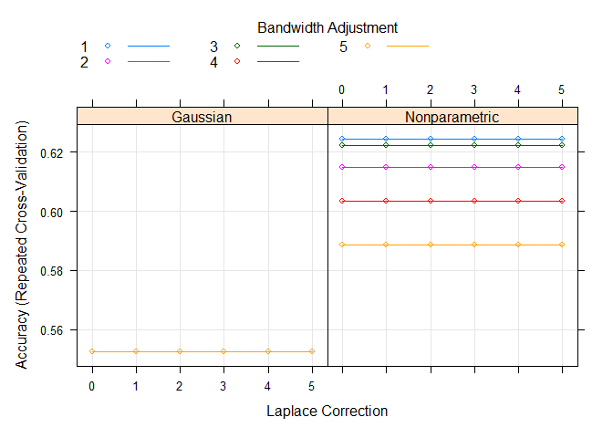

```r
# REPRESENTACIÓN GRÁFICA
plot(modelo_nb)
```

```r
# Predicciones
predicciones_nb <- predict(modelo_nb, newdata = data_test_prep,
                           type = "raw")
predicciones_nb
```

```
  [1] H  LD H  H  H  LD LD LD LD LD H  LD LD LD H  H  LD H  H  H  LD LD LD H  H
 [26] H  H  LD LD LD H  H  LD LD LD LD H  H  LD H  H  H  LD LD LD H  H  LD H  H
 [51] H  LD LD LD LD LD LD H  H  LD H  H  LD LD LD LD H  LD H  LD H  H  H  H  LD
 [76] LD H  H  H  H  H  LD H  LD H  H  LD H  H  LD H  H  LD H  H  H  H  LD H  H
[101] H  H  H  H  H  H  H  H  LD H  LD H  H  LD LD LD H  H  H  H  H  H  H  LD H
[126] LD H  LD H  LD LD H  H  H  H  LD H  H  H  H  H  H  H  H  H  LD LD LD LD H
[151] H  LD LD H  LD LD H  LD H  LD H  H  LD H  LD LD LD H  LD LD LD LD H
Levels: LD H
```

```r
# Evaluación
conf_mat_nb <- confusionMatrix(data = predicciones_nb, reference = data_test_prep$Class,
                               positive = "LD")
conf_mat_nb
```

```
Confusion Matrix and Statistics

          Reference
Prediction LD  H
        LD 68  7
        H  56 42

               Accuracy : 0.6358
                 95% CI : (0.5594, 0.7075)
    No Information Rate : 0.7168
    P-Value [Acc > NIR] : 0.9917

                  Kappa : 0.3114

 Mcnemar's Test P-Value : 1.472e-09

            Sensitivity : 0.5484
            Specificity : 0.8571
         Pos Pred Value : 0.9067
         Neg Pred Value : 0.4286
             Prevalence : 0.7168
         Detection Rate : 0.3931
   Detection Prevalence : 0.4335
      Balanced Accuracy : 0.7028

       'Positive' Class : LD
```

```r
stats_class_nb <- data.frame(model         = "NB",
                             accuracy      = conf_mat_nb$overall[[1]],
                             FN            = conf_mat_nb$table[2,1],
                             FP            = conf_mat_nb$table[1,2],
                             error.rate    = 1-conf_mat_nb$overall[[1]],
                             kappa         = conf_mat_nb$overall[[2]],
                             sensibilidad  = conf_mat_nb$byClass[[1]],
                             especificidad = conf_mat_nb$byClass[[2]],
                             precision     = conf_mat_nb$byClass[[5]],
                             recall        = conf_mat_nb$byClass[[6]],
                             f.measure     = conf_mat_nb$byClass[[7]])
stats_class_nb
```

```
  model  accuracy FN FP error.rate     kappa sensibilidad especificidad
1    NB 0.6358382 56  7  0.3641618 0.3113667    0.5483871     0.8571429
  precision    recall f.measure
1 0.9066667 0.5483871 0.6834171
```

## Modelo Artificial neural network (ANN)

Generamos el modelo ANN.

```r
# se recurre a validación cruzada repetida como método de validación.
# Número de particiones y repeticiones
particiones  <- 10
repeticiones <- 5

hiperparametros <- expand.grid(size = c(10, 20, 40, 60, 80, 90, 100,120),
                               decay = c(0.0001))


set.seed(123)
seeds <- vector(mode = "list", length = (particiones * repeticiones) + 1)
for (i in 1:(particiones * repeticiones)) {
  seeds[[i]] <- sample.int(1000, nrow(hiperparametros))
}
seeds[[(particiones * repeticiones) + 1]] <- sample.int(1000, 1)


# DEFINICIÓN DEL ENTRENAMIENTO
control_train <- trainControl(method = "repeatedcv", number = particiones,
                              repeats = repeticiones, seeds = seeds,
                              returnResamp = "final", verboseIter = FALSE,
                              allowParallel = TRUE)

# AJUSTE DEL MODELO
set.seed(342)
modelo_ann <- train(Class ~ ., data = data_train_prep,
                    method = "nnet",
                    tuneGrid = hiperparametros,
                    metric = "Accuracy",
                    trControl = control_train,
                    # Rango de inicializaci?n de los pesos
                    rang = c(-0.7, 0.7),
                    # Número m?ximo de pesos
                    # se aumenta para poder incluir m?s meuronas
                    MaxNWts = 2000,
                    # Para que no se muestre cada iteraci?n por pantalla
                    trace = FALSE)
modelo_ann
```

```
Neural Network

406 samples
 10 predictor
  2 classes: 'LD', 'H'

No pre-processing
Resampling: Cross-Validated (10 fold, repeated 5 times)
Summary of sample sizes: 365, 366, 365, 366, 366, 365, ...
Resampling results across tuning parameters:

  size  Accuracy   Kappa
   10   0.6984390  0.1742979
   20   0.6994878  0.1722425
   40   0.7003537  0.1850680
   60   0.6976585  0.1877724
   80   0.7107073  0.1947102
   90   0.7142073  0.2034146
  100   0.7126829  0.1934716
  120   0.7141463  0.2007273

Tuning parameter 'decay' was held constant at a value of 1e-04
Accuracy was used to select the optimal model using the largest value.
The final values used for the model were size = 90 and decay = 1e-04.
```

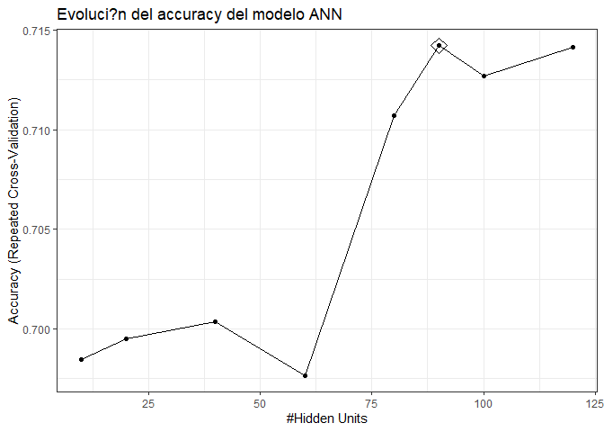

```r
# REPRESENTACIÓN GRÁFICA
ggplot(modelo_ann, highlight = TRUE) +
  labs(title = "Evoluci?n del accuracy del modelo ANN") +
  theme_bw()
```

```r
# Predicciones
predicciones_ann <- predict(modelo_ann, newdata = data_test_prep,
                            type = "raw")
predicciones_ann
```

```
  [1] LD LD LD H  H  LD LD LD LD LD LD LD LD LD LD H  LD LD LD LD LD LD LD LD H
 [26] LD LD LD LD LD LD LD LD LD LD LD LD H  LD LD LD LD LD LD LD H  LD LD LD H
 [51] LD LD LD LD LD LD LD LD LD LD H  LD LD LD LD LD H  LD H  LD H  H  LD LD LD
 [76] LD LD LD LD LD LD LD LD LD LD LD LD LD LD LD LD LD LD H  LD H  LD LD LD LD
[101] LD LD LD H  H  LD LD LD LD LD LD H  H  LD LD LD LD LD H  H  LD LD LD LD LD
[126] LD H  LD LD LD LD LD LD LD LD LD LD LD LD LD LD LD LD LD LD LD LD LD LD LD
[151] LD LD LD LD LD LD LD LD LD LD LD LD LD H  LD LD LD LD LD LD LD LD LD
Levels: LD H
```

```r
# Evaluación
conf_mat_ann <- confusionMatrix(data = predicciones_ann, reference = data_test_prep$Class,
                                positive = "LD")
conf_mat_ann
```

```
Confusion Matrix and Statistics

          Reference
Prediction  LD   H
        LD 116  35
        H    8  14

               Accuracy : 0.7514
                 95% CI : (0.6802, 0.8139)
    No Information Rate : 0.7168
    P-Value [Acc > NIR] : 0.1771

                  Kappa : 0.2654

 Mcnemar's Test P-Value : 7.341e-05

            Sensitivity : 0.9355
            Specificity : 0.2857
         Pos Pred Value : 0.7682
         Neg Pred Value : 0.6364
             Prevalence : 0.7168
         Detection Rate : 0.6705
   Detection Prevalence : 0.8728
      Balanced Accuracy : 0.6106

       'Positive' Class : LD
```

```r
stats_class_ann <- data.frame(model         = "ANN",
                              accuracy      = conf_mat_ann$overall[[1]],
                              FN            = conf_mat_ann$table[2,1],
                              FP            = conf_mat_ann$table[1,2],
                              error.rate    = 1-conf_mat_ann$overall[[1]],
                              kappa         = conf_mat_ann$overall[[2]],
                              sensibilidad  = conf_mat_ann$byClass[[1]],
                              especificidad = conf_mat_ann$byClass[[2]],
                              precision     = conf_mat_ann$byClass[[5]],
                              recall        = conf_mat_ann$byClass[[6]],
                              f.measure     = conf_mat_ann$byClass[[7]])
stats_class_ann
```

```
  model  accuracy FN FP error.rate     kappa sensibilidad especificidad
1   ANN 0.7514451  8 35  0.2485549 0.2654291    0.9354839     0.2857143
  precision    recall f.measure
1 0.7682119 0.9354839 0.8436364
```

## Modelo Multilayer perceptron (MLP)

Generamos el modelo MLP.

```r
# Se recurre a validación cruzada repetida como método de validación.
# Número de particiones y repeticiones
particiones  <- 10
repeticiones <- 5

# hiperparametros <- expand.grid(size = c(1:20),
#                                decay = c(0.0001, 0.1, 0.5))

hiperparametros <- expand.grid(size = c(1:5),
                               decay = c(0.0001))


set.seed(123)
seeds <- vector(mode = "list", length = (particiones * repeticiones) + 1)
for (i in 1:(particiones * repeticiones)) {
  seeds[[i]] <- sample.int(1000, nrow(hiperparametros))
}
seeds[[(particiones * repeticiones) + 1]] <- sample.int(1000, 1)


# DEFINICIÓN DEL ENTRENAMIENTO
control_train <- trainControl(method = "repeatedcv", number = particiones,
                              repeats = repeticiones, seeds = seeds,
                              returnResamp = "final", verboseIter = FALSE,
                              allowParallel = TRUE)

# AJUSTE DEL MODELO
set.seed(342)
modelo_mlp <- train(Class ~ ., data = data_train_prep,
                    method = "mlpWeightDecay",
                    tuneGrid = hiperparametros,
                    metric = "Accuracy",
                    trControl = control_train,
                    learnFunc = "Std_Backpropagation")
modelo_mlp
```

```
Multi-Layer Perceptron

406 samples
 10 predictor
  2 classes: 'LD', 'H'

No pre-processing
Resampling: Cross-Validated (10 fold, repeated 5 times)
Summary of sample sizes: 365, 366, 365, 366, 366, 365, ...
Resampling results across tuning parameters:

  size  Accuracy   Kappa
  1     0.7124024   0.0035829929
  2     0.7133902  -0.0006286217
  3     0.7114268  -0.0055775588
  4     0.7099756   0.0103339912
  5     0.7094146   0.0037339300

Tuning parameter 'decay' was held constant at a value of 1e-04
Accuracy was used to select the optimal model using the largest value.
The final values used for the model were size = 2 and decay = 1e-04.
```

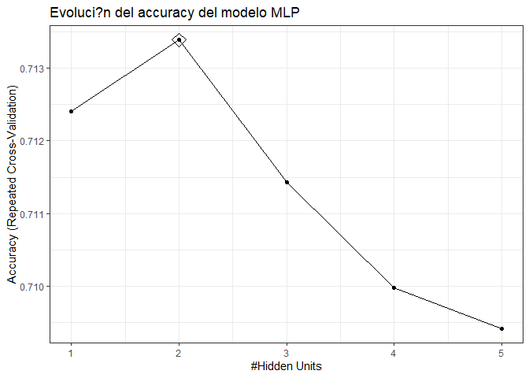

```r
# REPRESENTACIÓN GRÁFICA
ggplot(modelo_mlp, highlight = TRUE) +
  labs(title = "Evoluci?n del accuracy del modelo MLP") +
  theme_bw()
```

```r
# Predicciones
predicciones_mlp <- predict(modelo_mlp, newdata = data_test_prep,
                            type = "raw")
predicciones_mlp
```

```
  [1] LD LD LD LD LD LD LD LD LD LD LD LD LD LD LD LD LD LD LD LD LD LD LD LD LD
 [26] LD LD LD LD LD LD LD LD LD LD LD LD LD LD LD LD LD LD LD LD LD LD LD LD LD
 [51] LD LD LD LD LD LD LD LD LD LD LD LD LD LD LD LD LD LD LD LD LD LD LD LD LD
 [76] LD LD LD LD LD LD LD LD LD LD LD LD LD LD LD LD LD LD LD LD LD LD LD LD LD
[101] LD LD LD LD LD LD LD LD LD LD LD LD LD LD LD LD LD LD LD LD LD LD LD LD LD
[126] LD LD LD LD LD LD LD LD LD LD LD LD LD LD LD LD LD LD LD LD LD LD LD LD LD
[151] LD LD LD LD LD LD LD LD LD LD LD LD LD LD LD LD LD LD LD LD LD LD LD
Levels: LD H
```

```r
# Evaluación
conf_mat_mlp <- confusionMatrix(data = predicciones_mlp, reference = data_test_prep$Class,
                                positive = "LD")
conf_mat_mlp
```

```
Confusion Matrix and Statistics

          Reference
Prediction  LD   H
        LD 124  49
        H    0   0

               Accuracy : 0.7168
                 95% CI : (0.6434, 0.7825)
    No Information Rate : 0.7168
    P-Value [Acc > NIR] : 0.5384

                  Kappa : 0

 Mcnemar's Test P-Value : 7.025e-12

            Sensitivity : 1.0000
            Specificity : 0.0000
         Pos Pred Value : 0.7168
         Neg Pred Value :    NaN
             Prevalence : 0.7168
         Detection Rate : 0.7168
   Detection Prevalence : 1.0000
      Balanced Accuracy : 0.5000

       'Positive' Class : LD
```

```r
stats_class_mlp <- data.frame(model         = "MLP",
                              accuracy      = conf_mat_mlp$overall[[1]],
                              FN            = conf_mat_mlp$table[2,1],
                              FP            = conf_mat_mlp$table[1,2],
                              error.rate    = 1-conf_mat_mlp$overall[[1]],
                              kappa         = conf_mat_mlp$overall[[2]],
                              sensibilidad  = conf_mat_mlp$byClass[[1]],
                              especificidad = conf_mat_mlp$byClass[[2]],
                              precision     = conf_mat_mlp$byClass[[5]],
                              recall        = conf_mat_mlp$byClass[[6]],
                              f.measure     = conf_mat_mlp$byClass[[7]])
stats_class_mlp
```

```
  model accuracy FN FP error.rate kappa sensibilidad especificidad precision
1   MLP 0.716763  0 49   0.283237     0            1             0  0.716763
  recall f.measure
1      1 0.8350168
```

## Modelo Support vector machine linear kernel (SVM-lineal)

Generamos el modelo SVM-lineal.

```r
# se recurre a validación cruzada repetida como método de validación.
# Número de particiones y repeticiones
particiones  <- 10
repeticiones <- 5

hiperparametros <- data.frame(C = c(10,15,20,30,40,50))

set.seed(123)
seeds <- vector(mode = "list", length = (particiones * repeticiones) + 1)
for (i in 1:(particiones * repeticiones)) {
  seeds[[i]] <- sample.int(1000, nrow(hiperparametros))
}
seeds[[(particiones * repeticiones) + 1]] <- sample.int(1000, 1)


# DEFINICIÓN DEL ENTRENAMIENTO
control_train <- trainControl(method = "repeatedcv", number = particiones,
                              repeats = repeticiones, seeds = seeds,
                              returnResamp = "final", verboseIter = FALSE,
                              allowParallel = TRUE)


# AJUSTE DEL MODELO
set.seed(342)
modelo_svmlineal <- train(Class ~ ., data = data_train_prep,
                          method = "svmLinear",
                          tuneGrid = hiperparametros,
                          metric = "Accuracy",
                          trControl = control_train)

modelo_svmlineal
```

```
Support Vector Machines with Linear Kernel

406 samples
 10 predictor
  2 classes: 'LD', 'H'

No pre-processing
Resampling: Cross-Validated (10 fold, repeated 5 times)
Summary of sample sizes: 365, 366, 365, 366, 366, 365, ...
Resampling results across tuning parameters:

  C   Accuracy   Kappa
  10  0.7143902  0.001512605
  15  0.7143902  0.001512605
  20  0.7143902  0.001512605
  30  0.7148902  0.003805668
  40  0.7148902  0.003805668
  50  0.7153902  0.005937500

Accuracy was used to select the optimal model using the largest value.
The final value used for the model was C = 50.
```

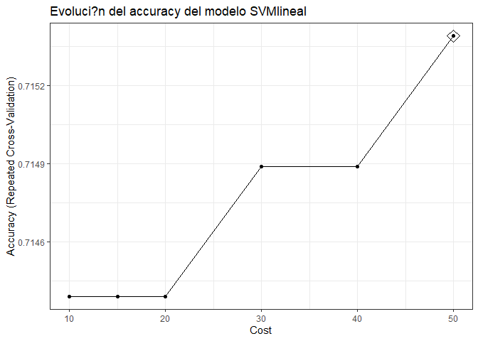

```r
# REPRESENTACIÓN GRÁFICA
ggplot(modelo_svmlineal, highlight = TRUE) +
  labs(title = "Evoluci?n del accuracy del modelo SVMlineal") +
  theme_bw()
```

```r
# Predicciones
predicciones_svmlineal <- predict(modelo_svmlineal, newdata = data_test_prep,
                                  type = "raw")
predicciones_svmlineal
```

```
  [1] LD LD LD LD LD LD LD LD LD LD LD LD LD LD LD LD LD LD LD LD LD LD LD LD LD
 [26] LD LD LD LD LD LD LD LD LD LD LD LD LD LD LD LD LD LD LD LD LD LD LD LD LD
 [51] LD LD LD LD LD LD LD LD LD LD LD LD LD LD LD LD LD LD LD LD LD LD LD LD LD
 [76] LD LD LD LD LD LD LD LD LD LD LD LD LD LD LD LD LD LD LD LD LD LD LD LD LD
[101] LD LD LD LD LD LD LD LD LD LD LD LD LD LD LD LD LD LD LD LD LD LD LD LD LD
[126] LD LD LD LD LD LD LD LD LD LD LD LD LD LD LD LD LD LD LD LD LD LD LD LD LD
[151] LD LD LD LD LD LD LD LD LD LD LD LD LD LD LD LD LD LD LD LD LD LD LD
Levels: LD H
```

```r
# Evaluación
conf_mat_svmlineal <- confusionMatrix(data = predicciones_svmlineal, reference = data_test_prep$Class,
                                      positive = "LD")
conf_mat_svmlineal
```

```
Confusion Matrix and Statistics

          Reference
Prediction  LD   H
        LD 124  49
        H    0   0

               Accuracy : 0.7168
                 95% CI : (0.6434, 0.7825)
    No Information Rate : 0.7168
    P-Value [Acc > NIR] : 0.5384

                  Kappa : 0

 Mcnemar's Test P-Value : 7.025e-12

            Sensitivity : 1.0000
            Specificity : 0.0000
         Pos Pred Value : 0.7168
         Neg Pred Value :    NaN
             Prevalence : 0.7168
         Detection Rate : 0.7168
   Detection Prevalence : 1.0000
      Balanced Accuracy : 0.5000

       'Positive' Class : LD
```

```r
stats_class_svmlineal <- data.frame(model         = "SVMlineal",
                                    accuracy      = conf_mat_svmlineal$overall[[1]],
                                    FN            = conf_mat_svmlineal$table[2,1],
                                    FP            = conf_mat_svmlineal$table[1,2],
                                    error.rate    = 1-conf_mat_svmlineal$overall[[1]],
                                    kappa         = conf_mat_svmlineal$overall[[2]],
                                    sensibilidad  = conf_mat_svmlineal$byClass[[1]],
                                    especificidad = conf_mat_svmlineal$byClass[[2]],
                                    precision     = conf_mat_svmlineal$byClass[[5]],
                                    recall        = conf_mat_svmlineal$byClass[[6]],
                                    f.measure     = conf_mat_svmlineal$byClass[[7]])
stats_class_svmlineal
```

```
      model accuracy FN FP error.rate kappa sensibilidad especificidad
1 SVMlineal 0.716763  0 49   0.283237     0            1             0
  precision recall f.measure
1  0.716763      1 0.8350168
```

## Modelo Support vector machine polynomial kernel (SVM-polynomial)

Generamos el modelo SVM-polynomial.

```r
# se recurre a validación cruzada repetida como método de validación.
# Número de particiones y repeticiones
particiones  <- 10
repeticiones <- 5


hiperparametros <- expand.grid(degree = c(2),
                               scale = c(0.1,0.2,0.3,0.5),
                               C = c(10,15,20,30,40,50))


set.seed(123)
seeds <- vector(mode = "list", length = (particiones * repeticiones) + 1)
for (i in 1:(particiones * repeticiones)) {
  seeds[[i]] <- sample.int(1000, nrow(hiperparametros))
}
seeds[[(particiones * repeticiones) + 1]] <- sample.int(1000, 1)


# DEFINICIÓN DEL ENTRENAMIENTO
control_train <- trainControl(method = "repeatedcv", number = particiones,
                              repeats = repeticiones, seeds = seeds,
                              returnResamp = "final", verboseIter = FALSE,
                              allowParallel = TRUE)

# AJUSTE DEL MODELO
set.seed(342)
modelo_svmPoly <- train(Class ~ ., data = data_train_prep,
                        method = "svmPoly",
                        tuneGrid = hiperparametros,
                        metric = "Accuracy",
                        trControl = control_train)

modelo_svmPoly
```

```
Support Vector Machines with Polynomial Kernel

406 samples
 10 predictor
  2 classes: 'LD', 'H'

No pre-processing
Resampling: Cross-Validated (10 fold, repeated 5 times)
Summary of sample sizes: 365, 366, 365, 366, 366, 365, ...
Resampling results across tuning parameters:

  scale  C   Accuracy   Kappa
  0.1    10  0.6823171  0.04291155
  0.1    15  0.6842439  0.07982814
  0.1    20  0.6975122  0.12519344
  0.1    30  0.6960366  0.13105293
  0.1    40  0.6965732  0.13000147
  0.1    50  0.6970488  0.13610391
  0.2    10  0.6916098  0.11389857
  0.2    15  0.6936220  0.12200588
  0.2    20  0.6930610  0.13040533
  0.2    30  0.6900854  0.12687668
  0.2    40  0.6871220  0.13389445
  0.2    50  0.6826829  0.13451471
  0.3    10  0.6890976  0.11662672
  0.3    15  0.6866463  0.11860626
  0.3    20  0.6832195  0.12401450
  0.3    30  0.6792195  0.13075529
  0.3    40  0.6737805  0.12610037
  0.3    50  0.6777561  0.14482245
  0.5    10  0.6747927  0.10975895
  0.5    15  0.6722927  0.11946945
  0.5    20  0.6747561  0.13359303
  0.5    30  0.6727683  0.13927394
  0.5    40  0.6777561  0.15952910
  0.5    50  0.6792195  0.16608142

Tuning parameter 'degree' was held constant at a value of 2
Accuracy was used to select the optimal model using the largest value.
The final values used for the model were degree = 2, scale = 0.1 and C = 20.
```

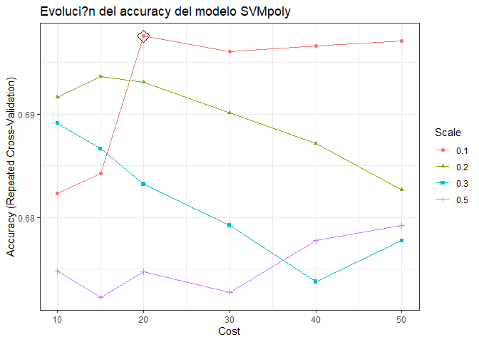

```r
# REPRESENTACIÓN GRÁFICA
ggplot(modelo_svmPoly, highlight = TRUE) +
  labs(title = "Evoluci?n del accuracy del modelo SVMpoly") +
  theme_bw()
```

```r
# Predicciones
predicciones_svmPoly <- predict(modelo_svmPoly, newdata = data_test_prep,
                                type = "raw")
predicciones_svmPoly
```

```
  [1] LD LD LD LD H  LD LD LD LD LD H  LD LD LD LD LD LD LD LD LD LD LD LD LD LD
 [26] H  H  LD H  LD H  LD LD LD LD LD LD H  LD H  LD H  LD LD H  LD LD LD LD LD
 [51] LD LD LD LD LD LD LD LD LD LD H  H  LD LD LD LD LD LD LD LD H  LD H  H  LD
 [76] H  LD LD LD LD LD LD LD LD LD LD LD LD LD LD LD LD LD LD LD LD LD LD LD LD
[101] LD LD LD H  LD LD H  LD LD LD H  H  LD LD LD LD LD LD H  H  LD LD LD LD LD
[126] LD LD LD LD LD LD LD LD LD LD H  LD H  LD LD LD LD LD H  LD LD LD LD LD LD
[151] LD LD LD LD LD LD LD LD LD LD LD LD LD H  LD LD LD LD LD LD LD LD LD
Levels: LD H
```

```r
# Evaluación
conf_mat_svmPoly <- confusionMatrix(data = predicciones_svmPoly, reference = data_test_prep$Class,
                                    positive = "LD")
conf_mat_svmPoly
```

```
Confusion Matrix and Statistics

          Reference
Prediction  LD   H
        LD 110  37
        H   14  12

               Accuracy : 0.7052
                 95% CI : (0.6312, 0.772)
    No Information Rate : 0.7168
    P-Value [Acc > NIR] : 0.667022

                  Kappa : 0.1538

 Mcnemar's Test P-Value : 0.002066

            Sensitivity : 0.8871
            Specificity : 0.2449
         Pos Pred Value : 0.7483
         Neg Pred Value : 0.4615
             Prevalence : 0.7168
         Detection Rate : 0.6358
   Detection Prevalence : 0.8497
      Balanced Accuracy : 0.5660

       'Positive' Class : LD
```

```r
stats_class_svmPoly <- data.frame(model         = "SVMpoly",
                                  accuracy      = conf_mat_svmPoly$overall[[1]],
                                  FN            = conf_mat_svmPoly$table[2,1],
                                  FP            = conf_mat_svmPoly$table[1,2],
                                  error.rate    = 1-conf_mat_svmPoly$overall[[1]],
                                  kappa         = conf_mat_svmPoly$overall[[2]],
                                  sensibilidad  = conf_mat_svmPoly$byClass[[1]],
                                  especificidad = conf_mat_svmPoly$byClass[[2]],
                                  precision     = conf_mat_svmPoly$byClass[[5]],
                                  recall        = conf_mat_svmPoly$byClass[[6]],
                                  f.measure     = conf_mat_svmPoly$byClass[[7]])
stats_class_svmPoly
```

```
    model  accuracy FN FP error.rate     kappa sensibilidad especificidad
1 SVMpoly 0.7052023 14 37  0.2947977 0.1538314    0.8870968      0.244898
  precision    recall f.measure
1 0.7482993 0.8870968 0.8118081
```

## Modelo Support vector machine radial kernel (SVM-radial)

Generamos el modelo SVM-radial.

```r
# se recurre a validación cruzada repetida como método de validación.
# Número de particiones y repeticiones
particiones  <- 10
repeticiones <- 5


hiperparametros <- expand.grid(sigma = c(0.1, 0.3, 0.5,1,3,5,10),
                               C = c(10,15,20,30,40,50))

set.seed(123)
seeds <- vector(mode = "list", length = (particiones * repeticiones) + 1)
for (i in 1:(particiones * repeticiones)) {
  seeds[[i]] <- sample.int(1000, nrow(hiperparametros))
}
seeds[[(particiones * repeticiones) + 1]] <- sample.int(1000, 1)


# DEFINICIÓN DEL ENTRENAMIENTO
control_train <- trainControl(method = "repeatedcv", number = particiones,
                              repeats = repeticiones, seeds = seeds,
                              returnResamp = "final", verboseIter = FALSE,
                              allowParallel = TRUE)

# AJUSTE DEL MODELO
set.seed(342)
modelo_svmRadial <- train(Class ~ ., data = data_train_prep,
                          method = "svmRadial",
                          tuneGrid = hiperparametros,
                          metric = "Accuracy",
                          trControl = control_train)
modelo_svmRadial
```

```
Support Vector Machines with Radial Basis Function Kernel

406 samples
 10 predictor
  2 classes: 'LD', 'H'

No pre-processing
Resampling: Cross-Validated (10 fold, repeated 5 times)
Summary of sample sizes: 365, 366, 365, 366, 366, 365, ...
Resampling results across tuning parameters:

  sigma  C   Accuracy   Kappa
   0.1   10  0.6719268  0.07976485
   0.1   15  0.6773415  0.12243484
   0.1   20  0.6812439  0.14846610
   0.1   30  0.6836463  0.16691954
   0.1   40  0.6885976  0.18473608
   0.1   50  0.6915854  0.20076634
   0.3   10  0.6782805  0.17035037
   0.3   15  0.6635000  0.14462492
   0.3   20  0.6590244  0.14507705
   0.3   30  0.6546220  0.13694060
   0.3   40  0.6546463  0.14075082
   0.3   50  0.6542317  0.14719030
   0.5   10  0.6748537  0.17342483
   0.5   15  0.6655244  0.16692590
   0.5   20  0.6709390  0.18804470
   0.5   30  0.6713902  0.19072683
   0.5   40  0.6699390  0.19253759
   0.5   50  0.6738780  0.20589787
   1.0   10  0.6970610  0.23457818
   1.0   15  0.6940976  0.22731130
   1.0   20  0.6931463  0.22647557
   1.0   30  0.6950732  0.23236375
   1.0   40  0.6945732  0.23164071
   1.0   50  0.6975122  0.23939989
   3.0   10  0.7290244  0.22829742
   3.0   15  0.7290244  0.22829742
   3.0   20  0.7290244  0.22829742
   3.0   30  0.7290244  0.22829742
   3.0   40  0.7290244  0.22829742
   3.0   50  0.7290244  0.22829742
   5.0   10  0.7143537  0.12467391
   5.0   15  0.7143537  0.12467391
   5.0   20  0.7143537  0.12467391
   5.0   30  0.7143537  0.12467391
   5.0   40  0.7143537  0.12467391
   5.0   50  0.7143537  0.12467391
  10.0   10  0.7084512  0.02756283
  10.0   15  0.7084512  0.02756283
  10.0   20  0.7084512  0.02756283
  10.0   30  0.7084512  0.02756283
  10.0   40  0.7084512  0.02756283
  10.0   50  0.7084512  0.02756283

Accuracy was used to select the optimal model using the largest value.
The final values used for the model were sigma = 3 and C = 10.
```

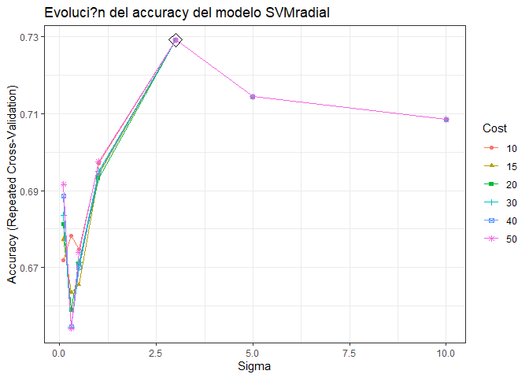

```r
# REPRESENTACIÓN GRÁFICA
ggplot(modelo_svmRadial, highlight = TRUE) +
  labs(title = "Evoluci?n del accuracy del modelo SVMradial") +
  theme_bw()
```

```r
# Predicciones
predicciones_svmRadial <- predict(modelo_svmRadial, newdata = data_test_prep,
                                  type = "raw")
predicciones_svmRadial
```

```
  [1] H  LD H  LD H  H  LD LD LD LD LD LD LD LD LD LD LD H  LD H  LD H  H  LD LD
 [26] LD LD LD LD LD LD LD LD LD LD LD LD LD LD LD H  H  LD LD LD LD H  LD H  LD
 [51] LD LD LD LD LD LD LD LD LD LD H  LD LD LD H  LD LD LD H  LD LD LD LD LD LD
 [76] LD LD LD LD LD LD LD H  LD H  LD LD LD LD H  H  LD LD H  H  H  LD LD H  LD
[101] LD LD LD LD LD LD LD LD LD LD H  LD H  LD LD LD LD H  H  H  LD LD LD LD LD
[126] LD LD LD LD LD LD LD LD H  LD LD LD LD LD LD LD H  LD LD H  LD LD LD LD LD
[151] LD LD LD LD LD LD LD LD LD LD LD LD LD H  LD LD LD LD LD LD LD LD H
Levels: LD H
```

```r
# Evaluación
conf_mat_svmRadial <- confusionMatrix(data = predicciones_svmRadial, reference = data_test_prep$Class,
                                      positive = "LD")
conf_mat_svmRadial
```

```
Confusion Matrix and Statistics

          Reference
Prediction  LD   H
        LD 107  33
        H   17  16

               Accuracy : 0.711
                 95% CI : (0.6373, 0.7773)
    No Information Rate : 0.7168
    P-Value [Acc > NIR] : 0.60427

                  Kappa : 0.2102

 Mcnemar's Test P-Value : 0.03389

            Sensitivity : 0.8629
            Specificity : 0.3265
         Pos Pred Value : 0.7643
         Neg Pred Value : 0.4848
             Prevalence : 0.7168
         Detection Rate : 0.6185
   Detection Prevalence : 0.8092
      Balanced Accuracy : 0.5947

       'Positive' Class : LD
```

```r
stats_class_svmRadial <- data.frame(model         = "SVMradial",
                                    accuracy      = conf_mat_svmRadial$overall[[1]],
                                    FN            = conf_mat_svmRadial$table[2,1],
                                    FP            = conf_mat_svmRadial$table[1,2],
                                    error.rate    = 1-conf_mat_svmRadial$overall[[1]],
                                    kappa         = conf_mat_svmRadial$overall[[2]],
                                    sensibilidad  = conf_mat_svmRadial$byClass[[1]],
                                    especificidad = conf_mat_svmRadial$byClass[[2]],
                                    precision     = conf_mat_svmRadial$byClass[[5]],
                                    recall        = conf_mat_svmRadial$byClass[[6]],
                                    f.measure     = conf_mat_svmRadial$byClass[[7]])
stats_class_svmRadial
```

```
      model  accuracy FN FP error.rate     kappa sensibilidad especificidad
1 SVMradial 0.7109827 17 33  0.2890173 0.2101899    0.8629032     0.3265306
  precision    recall f.measure
1 0.7642857 0.8629032 0.8106061
```

## Modelo Decision tree C5.0 sin hiperparámetros (C5.0)

Generamos el modelo C5.0.

```r
# se recurre a validación cruzada repetida como método de validación.
# Número de particiones y repeticiones
particiones  <- 10
repeticiones <- 5

hiperparametros <- data.frame(parameter = "none")


set.seed(123)
seeds <- vector(mode = "list", length = (particiones * repeticiones) + 1)
for (i in 1:(particiones * repeticiones)) {
  seeds[[i]] <- sample.int(1000, nrow(hiperparametros))
}
seeds[[(particiones * repeticiones) + 1]] <- sample.int(1000, 1)


# DEFINICIÓN DEL ENTRENAMIENTO
control_train <- trainControl(method = "repeatedcv", number = particiones,
                              repeats = repeticiones, seeds = seeds,
                              returnResamp = "final", verboseIter = FALSE,
                              allowParallel = TRUE)

# AJUSTE DEL MODELO
set.seed(342)
modelo_C5.0Tree <- train(Class ~ ., data = data_train_prep,
                         method = "C5.0Tree",
                         tuneGrid = hiperparametros,
                         metric = "Accuracy",
                         trControl = control_train)
modelo_C5.0Tree
```

```
Single C5.0 Tree

406 samples
 10 predictor
  2 classes: 'LD', 'H'

No pre-processing
Resampling: Cross-Validated (10 fold, repeated 5 times)
Summary of sample sizes: 365, 366, 365, 366, 366, 365, ...
Resampling results:

  Accuracy   Kappa
  0.6763049  0.1280689
```

```r
summary(modelo_C5.0Tree$finalModel)
```

```
Call:
C50:::C5.0.default(x = x, y = y, weights = wts)


C5.0 [Release 2.07 GPL Edition]     Fri Dec 17 22:06:23 2021
-------------------------------

Class specified by attribute `outcome'

Read 406 cases (11 attributes) from undefined.data

Decision tree:

TB > 0.05200946: LD (97/3)
TB <= 0.05200946:
:...Sgpt > 0.02763819: LD (52/5)
    Sgpt <= 0.02763819:
    :...Age > 0.7674419: LD (17/1)
        Age <= 0.7674419:
        :...Alkphos > 0.08074195:
            :...Gender_Male <= 0:
            :   :...TP <= 0.4492754: H (4)
            :   :   TP > 0.4492754: LD (13/2)
            :   Gender_Male > 0:
            :   :...Age <= 0.4069767:
            :       :...Sgot > 0.02521295: H (4)
            :       :   Sgot <= 0.02521295:
            :       :   :...Age <= 0.09302326: H (3)
            :       :       Age > 0.09302326:
            :       :       :...ALB <= 0.326087: H (2)
            :       :           ALB > 0.326087: LD (20/4)
            :       Age > 0.4069767:
            :       :...Age <= 0.627907: LD (20)
            :           Age > 0.627907:
            :           :...Age > 0.7093023: LD (4)
            :               Age <= 0.7093023:
            :               :...Alkphos <= 0.1194763: H (4)
            :                   Alkphos > 0.1194763: LD (6/1)
            Alkphos <= 0.08074195:
            :...DB > 0.03571429: LD (10/2)
```

[output cut: 35 more lines]

```

    Attribute usage:

    100.00% TB
     76.11% Sgpt
     63.30% Age
     59.11% Alkphos
     56.65% Gender_Male
     39.41% DB
      7.14% Sgot
      5.42% ALB
      4.19% TP


Time: 0.0 secs
```

```r
# Predicciones
predicciones_C5.0Tree <- predict(modelo_C5.0Tree, newdata = data_test_prep,
                                 type = "raw")
predicciones_C5.0Tree
```

```
  [1] LD LD H  LD H  LD LD LD LD LD LD LD LD LD LD H  LD LD H  H  LD LD LD H  LD
 [26] LD H  LD H  LD LD LD LD LD LD LD H  H  LD LD LD H  LD LD LD LD H  LD LD LD
 [51] LD LD LD LD LD LD LD LD H  LD LD H  LD LD H  LD H  LD LD LD H  H  H  H  LD
 [76] H  LD LD H  LD LD LD H  LD H  LD LD LD LD H  H  H  LD LD H  H  LD LD H  LD
[101] LD H  H  LD LD H  H  H  LD H  H  LD H  LD LD H  H  LD H  H  LD LD LD LD LD
[126] LD H  LD H  LD LD LD H  LD H  H  H  LD LD LD H  H  H  H  H  LD LD LD LD LD
[151] H  LD LD LD LD LD LD LD H  LD H  H  LD H  LD LD LD H  LD LD LD LD H
Levels: LD H
```

```r
# Evaluación
conf_mat_C5.0Tree <- confusionMatrix(data = predicciones_C5.0Tree, reference = data_test_prep$Class,
                                     positive = "LD")
conf_mat_C5.0Tree
```

```
Confusion Matrix and Statistics

          Reference
Prediction LD  H
        LD 93 20
        H  31 29

               Accuracy : 0.7052
                 95% CI : (0.6312, 0.772)
    No Information Rate : 0.7168
    P-Value [Acc > NIR] : 0.6670

                  Kappa : 0.3201

 Mcnemar's Test P-Value : 0.1614

            Sensitivity : 0.7500
            Specificity : 0.5918
         Pos Pred Value : 0.8230
         Neg Pred Value : 0.4833
             Prevalence : 0.7168
         Detection Rate : 0.5376
   Detection Prevalence : 0.6532
      Balanced Accuracy : 0.6709

       'Positive' Class : LD
```

```r
stats_class_C5.0Tree <- data.frame(model         = "C5.0Tree",
                                   accuracy      = conf_mat_C5.0Tree$overall[[1]],
                                   FN            = conf_mat_C5.0Tree$table[2,1],
                                   FP            = conf_mat_C5.0Tree$table[1,2],
                                   error.rate    = 1-conf_mat_C5.0Tree$overall[[1]],
                                   kappa         = conf_mat_C5.0Tree$overall[[2]],
                                   sensibilidad  = conf_mat_C5.0Tree$byClass[[1]],
                                   especificidad = conf_mat_C5.0Tree$byClass[[2]],
                                   precision     = conf_mat_C5.0Tree$byClass[[5]],
                                   recall        = conf_mat_C5.0Tree$byClass[[6]],
                                   f.measure     = conf_mat_C5.0Tree$byClass[[7]])
stats_class_C5.0Tree
```

```
     model  accuracy FN FP error.rate     kappa sensibilidad especificidad
1 C5.0Tree 0.7052023 31 20  0.2947977 0.3201048         0.75     0.5918367
  precision recall f.measure
1 0.8230088   0.75 0.7848101
```

## Modelo Decision tree C5.0 con hiperparámetros (C5.0)

Generamos el modelo C5.0.

```r
# se recurre a validación cruzada repetida como método de validación.
# Número de particiones y repeticiones
particiones  <- 10
repeticiones <- 5


# hiperparametros <- expand.grid(trials = c(10:15),
#                                model = "tree",
#                                winnow = c(TRUE, FALSE))

hiperparametros <- expand.grid(trials = c(10:15),
                               model = "tree",
                               winnow = c(FALSE))

set.seed(123)
seeds <- vector(mode = "list", length = (particiones * repeticiones) + 1)
for (i in 1:(particiones * repeticiones)) {
  seeds[[i]] <- sample.int(1000, nrow(hiperparametros))
}
seeds[[(particiones * repeticiones) + 1]] <- sample.int(1000, 1)


# DEFINICIÓN DEL ENTRENAMIENTO
control_train <- trainControl(method = "repeatedcv", number = particiones,
                              repeats = repeticiones, seeds = seeds,
                              returnResamp = "final", verboseIter = FALSE,
                              allowParallel = TRUE)

# AJUSTE DEL MODELO
set.seed(342)
modelo_C5.0 <- train(Class ~ ., data = data_train_prep,
                     method = "C5.0",
                     tuneGrid = hiperparametros,
                     metric = "Accuracy",
                     trControl = control_train)
modelo_C5.0
```

```
C5.0

406 samples
 10 predictor
  2 classes: 'LD', 'H'

No pre-processing
Resampling: Cross-Validated (10 fold, repeated 5 times)
Summary of sample sizes: 365, 366, 365, 366, 366, 365, ...
Resampling results across tuning parameters:

  trials  Accuracy   Kappa
  10      0.6856707  0.1682174
  11      0.6856707  0.1683747
  12      0.6866707  0.1709215
  13      0.6861707  0.1711748
  14      0.6861707  0.1711748
  15      0.6861707  0.1711748

Tuning parameter 'model' was held constant at a value of tree
Tuning
 parameter 'winnow' was held constant at a value of FALSE
Accuracy was used to select the optimal model using the largest value.
The final values used for the model were trials = 12, model = tree and winnow
 = FALSE.
```

```r
summary(modelo_C5.0$finalModel)
```

```
Call:
(function (x, y, trials = 1, rules = FALSE, weights = NULL, control
 = FALSE, sample = 0, earlyStopping = TRUE,     label = "outcome", seed
 = 1716L))


C5.0 [Release 2.07 GPL Edition]     Fri Dec 17 22:06:26 2021
-------------------------------

Class specified by attribute `outcome'

Read 406 cases (11 attributes) from undefined.data

-----  Trial 0:  -----

Decision tree:

TB > 0.05200946: LD (97/3)
TB <= 0.05200946:
:...Sgpt > 0.02763819: LD (52/5)
    Sgpt <= 0.02763819:
    :...Age > 0.7674419: LD (17/1)
        Age <= 0.7674419:
        :...Alkphos > 0.08074195:
            :...Gender_Male <= 0:
            :   :...TP <= 0.4492754: H (4)
            :   :   TP > 0.4492754: LD (13/2)
            :   Gender_Male > 0:
            :   :...Age <= 0.4069767:
            :       :...Sgot > 0.02521295: H (4)
            :       :   Sgot <= 0.02521295:
            :       :   :...Age <= 0.09302326: H (3)
            :       :       Age > 0.09302326:
            :       :       :...ALB <= 0.326087: H (2)
            :       :           ALB > 0.326087: LD (20/4)
            :       Age > 0.4069767:
            :       :...Age <= 0.627907: LD (20)
            :           Age > 0.627907:
            :           :...Age > 0.7093023: LD (4)
            :               Age <= 0.7093023:
```

[output cut: 48 more lines]

```

    Attribute usage:

    100.00% TB
     76.11% Sgpt
     63.30% Age
     59.11% Alkphos
     56.65% Gender_Male
     39.41% DB
      7.14% Sgot
      5.42% ALB
      4.19% TP


Time: 0.0 secs
```

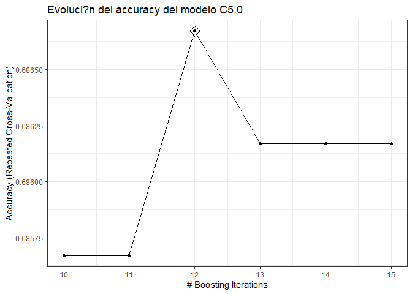

```r
# REPRESENTACIÓN GRÁFICA
ggplot(modelo_C5.0, highlight = TRUE) +
  labs(title = "Evoluci?n del accuracy del modelo C5.0") +
  theme_bw()
```

```r
# Predicciones
predicciones_C5.0 <- predict(modelo_C5.0, newdata = data_test_prep,
                             type = "raw")
predicciones_C5.0
```

```
  [1] LD LD H  LD H  LD LD LD LD LD LD LD LD LD LD H  LD LD H  H  LD LD LD H  LD
 [26] LD H  LD H  LD LD LD LD LD LD LD H  H  LD LD LD H  LD LD LD LD H  LD LD LD
 [51] LD LD LD LD LD LD LD LD H  LD LD H  LD LD H  LD H  LD LD LD H  H  H  H  LD
 [76] H  LD LD H  LD LD LD H  LD H  LD LD LD LD H  H  H  LD LD H  H  LD LD H  LD
[101] LD H  H  LD LD H  H  H  LD H  H  LD H  LD LD H  H  LD H  H  LD LD LD LD LD
[126] LD H  LD H  LD LD LD H  LD H  H  H  LD LD LD H  H  H  H  H  LD LD LD LD LD
[151] H  LD LD LD LD LD LD LD H  LD H  H  LD H  LD LD LD H  LD LD LD LD H
Levels: LD H
```

```r
# Evaluación
conf_mat_C5.0 <- confusionMatrix(data = predicciones_C5.0, reference = data_test_prep$Class,
                                 positive = "LD")
conf_mat_C5.0
```

```
Confusion Matrix and Statistics

          Reference
Prediction LD  H
        LD 93 20
        H  31 29

               Accuracy : 0.7052
                 95% CI : (0.6312, 0.772)
    No Information Rate : 0.7168
    P-Value [Acc > NIR] : 0.6670

                  Kappa : 0.3201

 Mcnemar's Test P-Value : 0.1614

            Sensitivity : 0.7500
            Specificity : 0.5918
         Pos Pred Value : 0.8230
         Neg Pred Value : 0.4833
             Prevalence : 0.7168
         Detection Rate : 0.5376
   Detection Prevalence : 0.6532
      Balanced Accuracy : 0.6709

       'Positive' Class : LD
```

```r
stats_class_C5.0 <- data.frame(model         = "C5.0",
                               accuracy      = conf_mat_C5.0$overall[[1]],
                               FN            = conf_mat_C5.0$table[2,1],
                               FP            = conf_mat_C5.0$table[1,2],
                               error.rate    = 1-conf_mat_C5.0$overall[[1]],
                               kappa         = conf_mat_C5.0$overall[[2]],
                               sensibilidad  = conf_mat_C5.0$byClass[[1]],
                               especificidad = conf_mat_C5.0$byClass[[2]],
                               precision     = conf_mat_C5.0$byClass[[5]],
                               recall        = conf_mat_C5.0$byClass[[6]],
                               f.measure     = conf_mat_C5.0$byClass[[7]])
stats_class_C5.0
```

```
  model  accuracy FN FP error.rate     kappa sensibilidad especificidad
1  C5.0 0.7052023 31 20  0.2947977 0.3201048         0.75     0.5918367
  precision recall f.measure
1 0.8230088   0.75 0.7848101
```

## Modelo Decision tree J48 (J48)

Generamos el modelo J48.

```r
# se recurre a validación cruzada repetida como método de validación.
# Número de particiones y repeticiones
particiones  <- 10
repeticiones <- 5

hiperparametros <- expand.grid(C = c(0.5),
                               M = c(2:10))

set.seed(123)
seeds <- vector(mode = "list", length = (particiones * repeticiones) + 1)
for (i in 1:(particiones * repeticiones)) {
  seeds[[i]] <- sample.int(1000, nrow(hiperparametros))
}
seeds[[(particiones * repeticiones) + 1]] <- sample.int(1000, 1)


# DEFINICIÓN DEL ENTRENAMIENTO
control_train <- trainControl(method = "repeatedcv", number = particiones,
                              repeats = repeticiones, seeds = seeds,
                              returnResamp = "final", verboseIter = FALSE,
                              allowParallel = TRUE)

# AJUSTE DEL MODELO
library(RWeka)
set.seed(342)
modelo_J48 <- train(Class ~ ., data = data_train_prep,
                    method = "J48",
                    tuneGrid = hiperparametros,
                    metric = "Accuracy",
                    trControl = control_train)
modelo_J48
```

```
C4.5-like Trees

406 samples
 10 predictor
  2 classes: 'LD', 'H'

No pre-processing
Resampling: Cross-Validated (10 fold, repeated 5 times)
Summary of sample sizes: 365, 366, 365, 366, 366, 365, ...
Resampling results across tuning parameters:

  M   Accuracy   Kappa
   2  0.6674390  0.10649348
   3  0.6753293  0.11857977
   4  0.6803049  0.13215691
   5  0.6773049  0.13180815
   6  0.6630122  0.08479430
   7  0.6620732  0.07562564
   8  0.6626220  0.08134477
   9  0.6630488  0.08180212
  10  0.6684390  0.10256544

Tuning parameter 'C' was held constant at a value of 0.5
Accuracy was used to select the optimal model using the largest value.
The final values used for the model were C = 0.5 and M = 4.
```

```r
summary(modelo_J48$finalModel)
```

```
=== Summary ===

Correctly Classified Instances         339               83.4975 %
Incorrectly Classified Instances        67               16.5025 %
Kappa statistic                          0.6146
Mean absolute error                      0.2261
Root mean squared error                  0.3362
Relative absolute error                 55.3257 %
Root relative squared error             74.422  %
Total Number of Instances              406

=== Confusion Matrix ===

   a   b   <-- classified as
 247  43 |   a = LD
  24  92 |   b = H
```

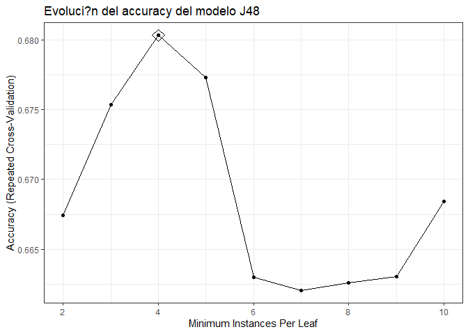

```r
# REPRESENTACIÓN GRÁFICA
ggplot(modelo_J48, highlight = TRUE) +
  labs(title = "Evoluci?n del accuracy del modelo J48") +
  theme_bw()
```

```r
# Predicciones
predicciones_J48 <- predict(modelo_J48, newdata = data_test_prep,
                            type = "raw")
predicciones_J48
```

```
  [1] LD LD H  LD H  LD LD LD LD LD LD LD LD LD LD H  LD LD H  H  LD LD LD LD LD
 [26] LD H  LD H  LD H  LD LD LD LD LD LD H  LD LD LD H  LD LD LD H  LD LD LD LD
 [51] LD LD LD LD LD LD LD LD H  LD LD H  LD LD H  LD H  LD LD LD H  H  H  H  LD
 [76] H  LD H  H  LD LD LD H  LD H  LD LD LD LD H  H  H  LD H  H  H  LD LD H  LD
[101] H  H  H  LD LD H  H  H  LD H  H  LD H  LD LD H  H  LD H  H  LD LD LD LD LD
[126] LD H  LD H  LD LD LD H  LD H  H  H  LD LD LD H  H  H  H  H  LD LD LD LD LD
[151] H  LD LD LD LD LD LD LD H  LD H  H  LD H  LD LD LD H  LD LD LD LD H
Levels: LD H
```

```r
# Evaluación
conf_mat_J48 <- confusionMatrix(data = predicciones_J48, reference = data_test_prep$Class,
                                positive = "LD")
conf_mat_J48
```

```
Confusion Matrix and Statistics

          Reference
Prediction LD  H
        LD 92 19
        H  32 30

               Accuracy : 0.7052
                 95% CI : (0.6312, 0.772)
    No Information Rate : 0.7168
    P-Value [Acc > NIR] : 0.66702

                  Kappa : 0.3279

 Mcnemar's Test P-Value : 0.09289

            Sensitivity : 0.7419
            Specificity : 0.6122
         Pos Pred Value : 0.8288
         Neg Pred Value : 0.4839
             Prevalence : 0.7168
         Detection Rate : 0.5318
   Detection Prevalence : 0.6416
      Balanced Accuracy : 0.6771

       'Positive' Class : LD
```

```r
stats_class_J48 <- data.frame(model         = "J48",
                              accuracy      = conf_mat_J48$overall[[1]],
                              FN            = conf_mat_J48$table[2,1],
                              FP            = conf_mat_J48$table[1,2],
                              error.rate    = 1-conf_mat_J48$overall[[1]],
                              kappa         = conf_mat_J48$overall[[2]],
                              sensibilidad  = conf_mat_J48$byClass[[1]],
                              especificidad = conf_mat_J48$byClass[[2]],
                              precision     = conf_mat_J48$byClass[[5]],
                              recall        = conf_mat_J48$byClass[[6]],
                              f.measure     = conf_mat_J48$byClass[[7]])
stats_class_J48
```

```
  model  accuracy FN FP error.rate     kappa sensibilidad especificidad
1   J48 0.7052023 32 19  0.2947977 0.3278738    0.7419355     0.6122449
  precision    recall f.measure
1 0.8288288 0.7419355 0.7829787
```

## Modelo Random forest (RF)

Generamos el modelo RF.

```r
# se recurre a validación cruzada repetida como método de validación.
# Número de particiones y repeticiones
particiones  <- 10
repeticiones <- 5


hiperparametros <- expand.grid(mtry = c(1:10),
                               min.node.size = c(4, 5, 10),
                               splitrule = c("gini"))


set.seed(123)
seeds <- vector(mode = "list", length = (particiones * repeticiones) + 1)
for (i in 1:(particiones * repeticiones)) {
  seeds[[i]] <- sample.int(1000, nrow(hiperparametros))
}
seeds[[(particiones * repeticiones) + 1]] <- sample.int(1000, 1)


# DEFINICIÓN DEL ENTRENAMIENTO
control_train <- trainControl(method = "repeatedcv", number = particiones,
                              repeats = repeticiones, seeds = seeds,
                              returnResamp = "final", verboseIter = FALSE,
                              allowParallel = TRUE)

# AJUSTE DEL MODELO
set.seed(342)
modelo_rf <- train(Class ~ ., data = data_train_prep,
                   method = "ranger",
                   tuneGrid = hiperparametros,
                   metric = "Accuracy",
                   trControl = control_train,
                   # Número de ?rboles ajustados
                   num.trees = 500)
modelo_rf
```

```
Random Forest

406 samples
 10 predictor
  2 classes: 'LD', 'H'

No pre-processing
Resampling: Cross-Validated (10 fold, repeated 5 times)
Summary of sample sizes: 365, 366, 365, 366, 366, 365, ...
Resampling results across tuning parameters:

  mtry  min.node.size  Accuracy   Kappa
   1     4             0.7117805  0.10980073
   1     5             0.7098780  0.10386738
   1    10             0.7072683  0.09125936
```

[output cut: 32 more lines]

```r
summary(modelo_rf$finalModel)
```

```
                          Length Class         Mode
predictions               406    factor        numeric
num.trees                   1    -none-        numeric
num.independent.variables   1    -none-        numeric
mtry                        1    -none-        numeric
min.node.size               1    -none-        numeric
prediction.error            1    -none-        numeric
forest                      9    ranger.forest list
confusion.matrix            4    table         numeric
splitrule                   1    -none-        character
treetype                    1    -none-        character
call                        9    -none-        call
importance.mode             1    -none-        character
num.samples                 1    -none-        numeric
replace                     1    -none-        logical
xNames                     10    -none-        character
problemType                 1    -none-        character
tuneValue                   3    data.frame    list
obsLevels                   2    -none-        character
param                       1    -none-        list
```

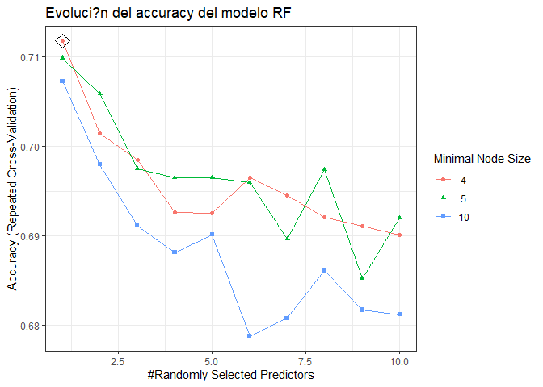

```r
# REPRESENTACIÓN GRÁFICA
ggplot(modelo_rf, highlight = TRUE) +
  labs(title = "Evoluci?n del accuracy del modelo RF") +
  theme_bw()
```

```r
# Predicciones
predicciones_rf <- predict(modelo_rf, newdata = data_test_prep,
                           type = "raw")
predicciones_rf
```

```
  [1] LD LD LD LD H  LD LD LD LD LD LD LD LD LD LD LD LD LD LD LD LD LD LD LD LD
 [26] LD LD LD LD LD LD LD LD LD LD LD H  H  LD LD LD LD LD LD LD LD LD LD LD LD
 [51] LD LD LD LD LD LD LD LD LD LD LD LD LD LD LD LD H  LD LD LD LD LD LD H  LD
 [76] LD LD LD LD LD LD LD LD LD LD LD LD LD LD LD LD LD LD H  LD LD LD LD H  LD
[101] LD H  LD LD LD LD LD H  LD H  LD LD LD LD LD LD LD LD LD LD LD LD LD LD LD
[126] LD H  LD H  LD LD LD LD LD LD LD LD LD LD LD LD H  LD LD LD LD LD LD LD LD
[151] LD LD LD LD LD LD LD LD H  LD LD LD LD H  LD LD LD LD LD LD LD LD LD
Levels: LD H
```

```r
# Evaluación
conf_mat_rf <- confusionMatrix(data = predicciones_rf, reference = data_test_prep$Class,
                               positive = "LD")
conf_mat_rf
```

```
Confusion Matrix and Statistics

          Reference
Prediction  LD   H
        LD 119  39
        H    5  10

               Accuracy : 0.7457
                 95% CI : (0.674, 0.8087)
    No Information Rate : 0.7168
    P-Value [Acc > NIR] : 0.2254

                  Kappa : 0.2072

 Mcnemar's Test P-Value : 6.527e-07

            Sensitivity : 0.9597
            Specificity : 0.2041
         Pos Pred Value : 0.7532
         Neg Pred Value : 0.6667
             Prevalence : 0.7168
         Detection Rate : 0.6879
   Detection Prevalence : 0.9133
      Balanced Accuracy : 0.5819

       'Positive' Class : LD
```

```r
stats_class_rf <- data.frame(model         = "RF",
                             accuracy      = conf_mat_rf$overall[[1]],
                             FN            = conf_mat_rf$table[2,1],
                             FP            = conf_mat_rf$table[1,2],
                             error.rate    = 1-conf_mat_rf$overall[[1]],
                             kappa         = conf_mat_rf$overall[[2]],
                             sensibilidad  = conf_mat_rf$byClass[[1]],
                             especificidad = conf_mat_rf$byClass[[2]],
                             precision     = conf_mat_rf$byClass[[5]],
                             recall        = conf_mat_rf$byClass[[6]],
                             f.measure     = conf_mat_rf$byClass[[7]])
stats_class_rf
```

```
  model  accuracy FN FP error.rate     kappa sensibilidad especificidad
1    RF 0.7456647  5 39  0.2543353 0.2072485    0.9596774     0.2040816
  precision    recall f.measure
1 0.7531646 0.9596774 0.8439716
```

## Modelo Logistic regression (LR)

Generamos el modelo LR.

```r
# se recurre a validación cruzada repetida como método de validación.
# Número de particiones y repeticiones
particiones  <- 10
repeticiones <- 5

hiperparametros <- data.frame(parameter = "none")


set.seed(123)
seeds <- vector(mode = "list", length = (particiones * repeticiones) + 1)
for (i in 1:(particiones * repeticiones)) {
  seeds[[i]] <- sample.int(1000, nrow(hiperparametros))
}
seeds[[(particiones * repeticiones) + 1]] <- sample.int(1000, 1)


# DEFINICIÓN DEL ENTRENAMIENTO
control_train <- trainControl(method = "repeatedcv", number = particiones,
                              repeats = repeticiones, seeds = seeds,
                              returnResamp = "final", verboseIter = FALSE,
                              allowParallel = TRUE)

# AJUSTE DEL MODELO
set.seed(342)
modelo_lrglm <- train(Class ~ ., data = data_train_prep,
                      method = "glm",
                      tuneGrid = hiperparametros,
                      metric = "Accuracy",
                      trControl = control_train,
                      family = "binomial")
modelo_lrglm
```

```
Generalized Linear Model

406 samples
 10 predictor
  2 classes: 'LD', 'H'

No pre-processing
Resampling: Cross-Validated (10 fold, repeated 5 times)
Summary of sample sizes: 365, 366, 365, 366, 366, 365, ...
Resampling results:

  Accuracy   Kappa
  0.7151341  0.1989561
```

```r
summary(modelo_lrglm$finalModel)
```

```
Call:
NULL

Deviance Residuals:
    Min       1Q   Median       3Q      Max
-1.6783  -0.9068  -0.3460   1.0354   3.1161

Coefficients:
            Estimate Std. Error z value Pr(>|z|)
(Intercept)   2.1833     0.8793   2.483  0.01302 *
Age          -1.4488     0.6596  -2.196  0.02806 *
TB            0.6234    22.1376   0.028  0.97753
DB          -10.7748    18.9327  -0.569  0.56928
Alkphos      -2.3806     2.0048  -1.187  0.23507
Sgpt        -29.3692    12.8148  -2.292  0.02192 *
Sgot         -2.9913    10.4470  -0.286  0.77463
TP           -9.5380     3.4363  -2.776  0.00551 **
ALB          11.6236     4.5188   2.572  0.01010 *
AG           -7.3896     3.7422  -1.975  0.04831 *
Gender_Male   0.1014     0.2921   0.347  0.72839
---
Signif. codes:  0 '***' 0.001 '**' 0.01 '*' 0.05 '.' 0.1 ' ' 1

(Dispersion parameter for binomial family taken to be 1)

    Null deviance: 485.79  on 405  degrees of freedom
Residual deviance: 391.92  on 395  degrees of freedom
AIC: 413.92

Number of Fisher Scoring iterations: 7
```

```r
# Predicciones
predicciones_lrglm <- predict(modelo_lrglm, newdata = data_test_prep,
                              type = "raw")
predicciones_lrglm
```

```
  [1] LD LD H  H  H  LD LD LD LD LD LD LD LD LD LD H  LD LD LD LD LD LD LD LD LD
 [26] LD LD LD LD LD H  LD LD LD LD LD LD H  LD LD LD LD LD LD LD H  LD LD LD LD
 [51] LD LD LD LD LD LD LD LD LD LD H  LD LD LD LD LD LD LD H  LD H  LD LD LD LD
 [76] LD LD LD LD LD LD LD LD LD LD LD LD LD LD LD LD LD LD H  LD H  LD LD LD LD
[101] LD LD LD H  H  LD LD LD LD LD LD H  H  LD LD LD LD LD H  H  H  LD LD LD LD
[126] LD LD LD LD LD LD LD LD LD LD LD LD LD LD LD LD LD LD LD LD LD LD LD LD LD
[151] LD LD LD LD LD LD LD LD LD LD LD LD LD H  LD LD LD LD LD LD LD LD LD
Levels: LD H
```

```r
# Evaluación
conf_mat_lrglm <- confusionMatrix(data = predicciones_lrglm, reference = data_test_prep$Class,
                                  positive = "LD")
conf_mat_lrglm
```

```
Confusion Matrix and Statistics

          Reference
Prediction  LD   H
        LD 116  37
        H    8  12

               Accuracy : 0.7399
                 95% CI : (0.6678, 0.8035)
    No Information Rate : 0.7168
    P-Value [Acc > NIR] : 0.2801

                  Kappa : 0.2197

 Mcnemar's Test P-Value : 2.993e-05

            Sensitivity : 0.9355
            Specificity : 0.2449
         Pos Pred Value : 0.7582
         Neg Pred Value : 0.6000
             Prevalence : 0.7168
         Detection Rate : 0.6705
   Detection Prevalence : 0.8844
      Balanced Accuracy : 0.5902

       'Positive' Class : LD
```

```r
stats_class_lrglm <- data.frame(model         = "LRglm",
                                accuracy      = conf_mat_lrglm$overall[[1]],
                                FN            = conf_mat_lrglm$table[2,1],
                                FP            = conf_mat_lrglm$table[1,2],
                                error.rate    = 1-conf_mat_lrglm$overall[[1]],
                                kappa         = conf_mat_lrglm$overall[[2]],
                                sensibilidad  = conf_mat_lrglm$byClass[[1]],
                                especificidad = conf_mat_lrglm$byClass[[2]],
                                precision     = conf_mat_lrglm$byClass[[5]],
                                recall        = conf_mat_lrglm$byClass[[6]],
                                f.measure     = conf_mat_lrglm$byClass[[7]])
stats_class_lrglm
```

```
  model  accuracy FN FP error.rate     kappa sensibilidad especificidad
1 LRglm 0.7398844  8 37  0.2601156 0.2197053    0.9354839      0.244898
  precision    recall f.measure
1 0.7581699 0.9354839 0.8375451
```